# Bayesian Attribute-Level Model (exploratory)

Brenden Eum

2026-11-06

Exploratory notebook. Can the Bayesian sequential-sampling model of Frömer, Callaway, Griffiths & Shenhav (2025, *Open Mind*), extended to attributes, explain the range-sensitive and reference-dependent attention weights in the paper? Nothing here is in the paper yet.

The notebook is written so that, if the results hold up, its sections can be moved into `Main_Analysis.Rmd` by cut-and-paste. The first section copies the main notebook’s preamble, data chunks and plot helpers (delete those copies when porting; the data cleaning itself already lives in `code/utilities/build_boxlong.R`, which the main notebook can switch to). Everything model-specific lives in scripts under `code/`:

- `code/simulation/simulate_bayesian_attributes.R`: the model and its choice probabilities (exact, computed on a grid of utility values by `code/simulation/exact_choice_prob.cpp`, C++ via Rcpp)
- `code/fitting/fit_bayesian_attributes.R`: maximum-likelihood fitting, cross-validation, the list of variants
- `code/fitting/run_bayesian_fits.R`: fits every variant and runs the cross-validation from a terminal (every fold is a full refit of about an hour; see the script header), caching to `results/cache/bayesian_model/`
- `code/parameter_recovery/recover_bayesian_attributes.R`: parameter recovery for the main model, from a terminal (one to five hours per dataset, longer the larger the true $\lambda$; the datasets can be split over processes)
- `code/fitting/run_all_bayesian_fits.sh`: runs all of the above as a queue of jobs, seven at a time (13 hours on an 8-core laptop)

This notebook loads those caches. With `RUN_FITS <- TRUE` it fits any variant whose cache is missing (slow); with `FALSE` it skips it.

Sections:

1. Copied preamble and data
2. Model
3. Sanity checks
4. Parameter recovery
5. Fits and cross-validation
6. Out-of-sample attention weights: main and supplementary figures, tables
7. Sampling noise by range condition (bootstrap over participants)
8. Notes

# Copied from Main_Analysis.Rmd (delete when porting)

```r
library(tidyverse)
library(brms)          # only to read the cached attention-weight fits (as_draws_df)
library(bayestestR)    # highest density intervals
library(patchwork)     # combining ggplots into one figure
library(knitr)         # kable() for the LaTeX tables

# Project utilities: the plot theme (.myPlot), the Narrow / Wide color and
# shape scales (.wn_colors, .wn_shapes), figure size defaults (.figw, .figh,
# .linewidth), `paths`, and build_pas() / build_boxlong().
source(here::here("code/utilities/getAllUtilities.R"))
```

```r
# Fit a variant inside the notebook when its cache is missing? Every fold of
# the cross-validation is a full refit, so a variant takes hours;
# code/fitting/run_bayesian_fits.R does the same from a terminal. With FALSE,
# variants without a cache are skipped.
RUN_FITS <- TRUE

# Where things live (absolute paths built from config/paths.yaml).
data_dir   <- file.path(paths$root, paths$data$processed)
fig_dir    <- file.path(paths$root, paths$paper_figures)
tab_dir    <- file.path(paths$root, paths$paper_tables)
fit_dir    <- file.path(paths$root, paths$notebooks, "brm_fits")        # cached brms fits (the data's cell weights)
cache_dir  <- file.path(paths$root, paths$results$cache, "bayesian_model")
nb_fig_dir <- file.path(paths$root, paths$notebooks, "notebook_figures")
for (d in c(fig_dir, tab_dir, cache_dir, nb_fig_dir)) dir.create(d, showWarnings = FALSE, recursive = TRUE)
```

```r
# Layout conventions (same as the main notebook): Narrow vs Wide by color and
# marker, attribute type by facet, study as a title over each panel.
study_labels <- as_labeller(c("1" = "Study 1", "2" = "Study 2"))
type_labels  <- as_labeller(c("N" = "Aversive (N)", "B" = "Ambivalent (B)", "P" = "Appetitive (P)"))

strip_style <- theme(
  strip.background = element_blank(),
  strip.text       = element_text(size = .title_pt * .fontscale, face = "bold")
)
type_strip_style <- theme(
  strip.background = element_blank(),
  strip.text       = element_text(size = .strip_pt * .fontscale)
)
study_title <- theme(plot.title = element_text(hjust = 0.5, face = "bold", size = .title_pt * .fontscale))

wn_scales <- list(
  scale_color_manual(name = "Range", values = .wn_colors),
  scale_shape_manual(name = "Range", values = .wn_shapes)
)
wn_dodge <- position_dodge(width = 2)

# x-axis ticks for the N / B / P facets (every other value of the Wide range).
x_attr_breaks <- function(limits) {
  if (limits[2] < 0) return(c(-50, -30, -10))   # aversive facet
  if (limits[1] > 0) return(c(10, 30, 50))      # appetitive facet
  c(-20, 0, 20)                                 # ambivalent facet
}

legend_right <- theme(legend.position = "right")
pt_size      <- 0
pt_linewidth <- 0.7
```

```r
pas_raw <- read_csv(file.path(data_dir, "main_data.csv"), show_col_types = FALSE)
pas     <- build_pas(pas_raw)      # the main notebook's clean-trial chunk, as a function
boxlong <- build_boxlong(pas)      # the main notebook's boxlong chunk, as a function
```

```r
# Design matrix for the cell-weight regression (the main notebook's
# flex-design chunk, generalized). `bl` is box-level data and `ps` trial-level
# data; both need a `TrialKey` column (Trial for the real data; Trial_rep for
# simulated data, where every rep of a trial counts as a new trial) and a
# `ChooseL` column. Returns one row per trial: ChooseL, Study, the three
# signed value channels SV_P / SV_N / SV_B, and the signed dwell in every
# (type x value) cell (0 where the cell wasn't on screen).
build_flex_dat <- function(range, bl, ps) {
  bl <- bl %>% filter(WN == range)
  ps <- ps %>% filter(WN == range)

  flex_design <- bl %>%
    group_by(Subject, TrialKey, cell) %>%
    summarise(sd = sum(signed_dwell), .groups = "drop") %>%
    pivot_wider(names_from = cell, values_from = sd, values_fill = 0)

  value_design <- bl %>%
    group_by(Subject, TrialKey, type) %>%
    summarise(SV = sum(signed_value), .groups = "drop") %>%
    pivot_wider(names_from = type, values_from = SV, names_prefix = "SV_", values_fill = 0)

  ps %>%
    transmute(Subject, TrialKey, ChooseL, Study = factor(Study)) %>%
    left_join(value_design, by = c("Subject", "TrialKey")) %>%
    left_join(flex_design,  by = c("Subject", "TrialKey"))
}

# The main text's specification (the main notebook's build_flex_dat): one row
# per trial with ChooseL, S2 (1 for Study 2), the signed presence U_<cell> of
# every cell except each type's lowest value, which is the reference (+1 in
# the left option, -1 in the right, 0 off screen), and the signed dwell in
# every cell. Pooled over the studies.
build_utility_dat <- function(range, bl, ps) {
  bl <- bl %>% filter(WN == range)
  ps <- ps %>% filter(WN == range)

  dwell_design <- bl %>%
    group_by(Subject, TrialKey, cell) %>%
    summarise(sd = sum(signed_dwell), .groups = "drop") %>%
    pivot_wider(names_from = cell, values_from = sd, values_fill = 0)

  util_design <- bl %>%
    group_by(Subject, TrialKey, cell) %>%
    summarise(sp = sum(side_sign), .groups = "drop") %>%
    pivot_wider(names_from = cell, values_from = sp, values_fill = 0, names_prefix = "U_")
  ref_cells   <- bl %>% distinct(type, value, cell) %>% group_by(type) %>% slice_min(value, n = 1) %>% pull(cell)
  util_design <- util_design %>% select(-all_of(paste0("U_", ref_cells)))

  ps %>%
    transmute(Subject, TrialKey, ChooseL, S2 = as.integer(Study == 2)) %>%
    left_join(util_design,  by = c("Subject", "TrialKey")) %>%
    left_join(dwell_design, by = c("Subject", "TrialKey"))
}
util_cols  <- function(dat) str_subset(names(dat), "^U_")
dwell_cols <- function(dat) str_subset(names(dat), "^[PNB]_(neg|pos)[0-9]+$")
```

```r
# Signed attention weights by type and value, Narrow and Wide overlaid (the
# main notebook's plot_weights_by_range, plus a `ylim` argument; NULL = free).
plot_weights_by_range <- function(weights, title, ylim = c(-0.5, 0.5)) {
  p <- ggplot(weights, aes(x = value, y = estimate, color = WN, shape = WN)) +
    facet_wrap(~ type, scales = "free_x", labeller = type_labels) +
    geom_hline(yintercept = 0, linetype = "dotted", color = "grey50") +
    geom_line(linewidth = .linewidth, position = wn_dodge) +
    geom_pointrange(aes(ymin = lo, ymax = hi), size = pt_size, linewidth = .linewidth, position = wn_dodge) +
    wn_scales +
    labs(x = "Attribute Value", y = "Attention Weight", title = title) +
    .myPlot + type_strip_style + study_title + legend_right + theme(legend.direction = "vertical") +
    scale_x_continuous(breaks = x_attr_breaks)
  if (!is.null(ylim)) p <- p + coord_cartesian(ylim = ylim)
  p
}

# Data (points with 95% intervals, no connecting lines) and one model (lines,
# no points) in the same panels, Narrow and Wide overlaid: geometry tells data
# from model, color tells the range condition. The model's own 95% HDIs are
# not drawn.
plot_overlay <- function(data_w, model_w, title, ylim = c(-0.5, 0.5)) {
  p <- ggplot(mapping = aes(x = value, color = WN)) +
    facet_wrap(~ type, scales = "free_x", labeller = type_labels) +
    geom_hline(yintercept = 0, linetype = "dotted", color = "grey50") +
    geom_line(data = model_w, aes(y = estimate, group = WN), linewidth = .linewidth, position = wn_dodge) +
    geom_pointrange(data = data_w, aes(y = estimate, ymin = lo, ymax = hi, shape = WN),
                    size = pt_size, linewidth = .linewidth, position = wn_dodge) +
    wn_scales +
    labs(x = "Attribute Value", y = "Attention Weight", title = title) +
    .myPlot + type_strip_style + study_title + legend_right + theme(legend.direction = "vertical") +
    scale_x_continuous(breaks = x_attr_breaks)
  if (!is.null(ylim)) p <- p + coord_cartesian(ylim = ylim)
  p
}
```

```r
# The data's cell weights under the main text's specification: posterior
# medians and 95% HDIs from the main notebook's two cached brms fits
# (utilities and cell weights, pooled over the studies). Each fit is ~1.4 GB,
# so the summary is cached after the first extraction. These are the numbers
# the paper quotes, and the data points of the figures and the data side of
# the fits table's error column. `se` is the posterior SD (for the error
# column's noise floor). The data's plain-regression weights
# (weights_data_glm, in the oos-weights chunk) are kept for comparison.
data_weights_file <- file.path(cache_dir, "data_cell_weights_utility.rds")
if (file.exists(data_weights_file)) {
  weights_data <- readRDS(data_weights_file)
} else {
  weights_data <- tibble()
  for (rng in c("Narrow", "Wide")) {
    f <- file.path(fit_dir, paste0("attention_weights_utility_", tolower(rng), ".rds"))
    if (!file.exists(f)) { cat("No cached fit", f, "\n"); next }
    draws <- as_draws_df(readRDS(f), variable = "^b_", regex = TRUE)
    cells <- names(draws) %>% str_subset("^b_[PNB]_(neg|pos)[0-9]+$") %>% str_remove("^b_")
    for (cell in cells) {
      x <- draws[[paste0("b_", cell)]]
      h <- bayestestR::hdi(x, ci = 0.95)
      weights_data <- bind_rows(weights_data, tibble(
        WN = rng, term = cell, estimate = median(x), se = sd(x), lo = h$CI_low, hi = h$CI_high
      ))
    }
    rm(draws); invisible(gc())
  }
  if (nrow(weights_data) > 0) {
    weights_data <- weights_data %>% mutate(
      type  = factor(str_sub(term, 1, 1), levels = c("N", "B", "P")),
      value = as.numeric(str_extract(term, "[0-9]+$")) * if_else(str_detect(term, "_neg"), -1, 1),
      WN    = factor(WN, levels = c("Narrow", "Wide"))
    )
    saveRDS(weights_data, data_weights_file)
  }
}
```

# Model

Every box (option x attribute) is an item whose value the participant estimates by sampling while the box is hovered. The estimate starts at a prior mean and moves toward what was seen; how far it moves depends on how long the box was looked at and on how noisy looking is. This is Frömer et al.’s model with two changes: the items are attributes, and an option’s value is the sum of its two attribute estimates, each valued relative to the prior mean with loss aversion.

**Where the range enters.** A box is measured against a reference distribution with mean $\mu_D$, SD $s_D$, minimum and maximum. The prior reference is either the six values the box’s attribute type can take in the participant’s range condition (one prior per type x range) or all eighteen values of the range condition (one prior per range, shared by P, N and B). Values and noise are in points for every current variant. Because every subject is in one range condition and has their own noise, differences in noise between conditions are absorbed by the subjects’ $\sigma$ whatever the units are, so the units only matter for how the attribute types are weighted within a condition; an earlier round of fits showed that weighting per point beats weighting by each type’s spread, which is why only points are kept.

**Prior.** $\mathcal{N}(m_0, s_p^2)$: $m_0$ sits a fraction $q$ of the way from the reference’s minimum to its maximum ($q = 0.5$ is the middle), and $s_p = s_D$, the spread of the reference. (An earlier round fitted the ratio $s_p / s_D$ freely and found 1.07 and 1.17, so it is now fixed at 1.) The zero prior fixes $m_0$ at an objective 0, which for the symmetric spans of this design is $q = 0.5$; the flat prior keeps that mean and sets $s_p$ to 1000 $s_D$, so the prior carries no weight in the estimate, but its mean still serves as the reference of the loss-aversion kink below.

**Sampling and loss aversion.** For a box with value $a$ after $t$ seconds of dwell,

$$w = \frac{t / \sigma^2}{1 / s_p^2 + t / \sigma^2}, \qquad
m = m_0 + w\,(\bar{x} - m_0), \quad \bar{x} \sim \mathcal{N}(a, \sigma^2
/ t),$$

and the box is valued relative to the prior mean with a kink, $u(m) = m_0 + (m - m_0)$ if $m \ge m_0$ and $u(m) = m_0 + \lambda (m - m_0)$ if $m < m_0$. With $\lambda > 1$ attention repels more strongly from a box whose estimate sits below the reference than it attracts toward one above it; $\lambda = 1$ is the plain model. An option’s estimate is the sum of its two boxes’ $u(m)$; the larger one is chosen. We do not see the samples a participant drew, only how long they looked, so a choice has a probability: the chance, over the samples they might have drawn, that the left option’s estimate comes out higher. Given the dwell times each $m$ is normal, so each box’s $u(m)$ is a normal whose lower half is stretched by $\lambda$. With $\lambda = 1$ nothing is stretched, $V_L - V_R$ is normal, and the probability is the probit $\Phi(\Delta / \sqrt{v})$ with $\Delta$ and $v$ its mean and variance, which have closed forms. With $\lambda \ne 1$ the difference is not normal and that probit is only an approximation (off by up to 0.006 per trial at the fitted $\lambda$, about 1.6 log-likelihood units in all, and by far more at $\lambda = 2.5$), so the probability is computed exactly instead: every box’s utility is laid on a grid of values, each option’s utility is the sum of its boxes, and the left option is compared with the right cell by cell. The grid’s error shrinks with the square of its spacing, so the calculation is run at spacings $h$, $h/2$ and $h/4$ ($h$ = half the trial’s smallest box SD) and extrapolated to zero spacing, which removes the leading error terms. The probit is kept where it is exact: $\lambda = 1$ (stages 1 and 2 of the fit), and trials in which every box is more than 8.3 SDs from the reference point, so that no box can land on its stretched side. The sanity checks compare the exact probabilities with a box-by-box simulation and with the probit. Trials with a box that was never hovered (NA dwell) are dropped, as the paper’s regressions drop them.

**Parameters and error model.** $\sigma$ (noise per second) is a random effect: in each range condition $\log \sigma$ is normal with mean $\mu$ and SD $\tau$, both fitted, and a subject’s likelihood is the probability of their choices averaged over that distribution (the marginal likelihood, as in a mixed-effects regression). The average is a sum over a grid of 60 values of $\log \sigma$ from 0.005 to 500 points per second with weights proportional to the normal density, so the population is a normal truncated to that range; a finer grid changes nothing to four decimals. $q$ per range condition; $\lambda$ shared by both conditions (the `cond_lamcond` variant fits it per condition as a check). All group parameters are pooled across subjects. One algorithm fits every variant, and the variants differ only in which group parameters are free: the zero and flat priors fix $q$ at 0.5 and fit the population and $\lambda$ like the others. Averaging over $\sigma$ replaces an earlier penalised fit of one $\sigma$ per subject (a hand-set pull of $\log \sigma$ toward the group median): plain maximum likelihood sends the $\sigma$ of a subject with 30 correct trials to zero, and a held-out error then costs 25+ log-likelihood units; here, how far a subject’s own trials pull them away from the population is set by $\tau$, which the data choose. For reporting, a subject’s $\sigma$ is their posterior mean, and predictions average the choice probability over that posterior.

**Variants.** `cond_lam` (per-condition prior, loss aversion), `cond_lam1` (same, $\lambda = 1$), `type_lam` and `type_lam1` (per-type prior with and without loss aversion), `cond_lamcond` ($\lambda$ per condition), `zero` (prior mean at an objective 0, Frömer et al.’s ZERO PRIOR, with loss aversion around it) and `flat` (no pull toward a prior, loss aversion around 0). The paper’s comparison table carries `cond_lam`, `cond_lam1`, `type_lam`, `zero` and `flat`.

```r
source(here::here("code/simulation/simulate_bayesian_attributes.R"))
source(here::here("code/fitting/fit_bayesian_attributes.R"))
variants <- bayesian_variants()
str(variants, max.level = 1)
```

```
## List of 7
##  $ cond_lam    :List of 5
##  $ cond_lam1   :List of 5
##  $ type_lam    :List of 5
##  $ type_lam1   :List of 5
##  $ cond_lamcond:List of 5
##  $ zero        :List of 5
##  $ flat        :List of 5
```

```r
# Cell-weight regression by plain logistic regression (no random effects, as
# Frömer et al. did for simulated data), one fit per range condition and
# study. `bl` and `ps` need TrialKey and ChooseL columns (see build_flex_dat).
# Returns the cell weights and the three value slopes, with Wald 95% CIs.
cell_weight_glm <- function(bl, ps) {
  weights <- tibble()
  slopes  <- tibble()
  for (rng in c("Narrow", "Wide")) {
    dat   <- build_flex_dat(rng, bl, ps)
    cells <- setdiff(names(dat), c("Subject", "TrialKey", "ChooseL", "Study", "SV_P", "SV_N", "SV_B"))
    f     <- as.formula(paste("ChooseL ~ SV_P + SV_N + SV_B +", paste(cells, collapse = " + ")))
    for (s in 1:2) {
      fit <- glm(f, family = binomial, data = dat %>% filter(Study == s))
      co  <- summary(fit)$coefficients
      est <- tibble(term = rownames(co), estimate = co[, 1], se = co[, 2]) %>%
        mutate(lo = estimate - 1.96 * se, hi = estimate + 1.96 * se, Study = s, WN = rng)
      weights <- bind_rows(weights, est %>% filter(term %in% cells))
      slopes  <- bind_rows(slopes,  est %>% filter(str_starts(term, "SV_")))
    }
  }
  weights <- weights %>% mutate(
    type  = factor(str_sub(term, 1, 1), levels = c("N", "B", "P")),
    value = as.numeric(str_extract(term, "[0-9]+$")) * if_else(str_detect(term, "_neg"), -1, 1),
    WN    = factor(WN, levels = c("Narrow", "Wide"))
  )
  slopes <- slopes %>% mutate(
    type = factor(str_remove(term, "SV_"), levels = c("N", "B", "P")),
    WN   = factor(WN, levels = c("Narrow", "Wide"))
  )
  list(weights = weights, slopes = slopes)
}

# Simulated choices -> attention weights. `trials` needs Subject, Trial, WN,
# Study and p_left (the model's probability of choosing left). Every rep of a
# trial is treated as a new trial (TrialKey = Trial_rep).
simulated_weights <- function(trials, reps = 10, seed = 1) {
  sims <- simulate_choices_from_prob(trials, reps, seed) %>%
    transmute(Subject, Trial, WN, Study, TrialKey = Trial_rep, ChooseL = ChooseL_sim)
  bl_sim <- boxlong %>% select(-ChooseL) %>%
    inner_join(sims %>% select(Subject, Trial, TrialKey, ChooseL), by = c("Subject", "Trial"),
               relationship = "many-to-many")   # 4 boxes x reps per trial
  cell_weight_glm(bl_sim, sims)
}

# The main text's specification (utilities and cell weights, pooled over the
# studies) as one plain logistic regression per range condition: the data's
# comparison rows. Returns the cell weights with Wald 95% CIs, parsed into
# type and value.
utility_weight_glm <- function(bl, ps) {
  weights <- tibble()
  for (rng in c("Narrow", "Wide")) {
    dat <- build_utility_dat(rng, bl, ps)
    f   <- as.formula(paste("ChooseL ~ 1 + S2 +", paste(util_cols(dat), collapse = " + "), "+",
                            paste(dwell_cols(dat), collapse = " + ")))
    fit <- glm(f, family = binomial, data = dat)
    co  <- summary(fit)$coefficients
    weights <- bind_rows(weights, tibble(WN = rng, term = rownames(co), estimate = co[, 1], se = co[, 2]) %>%
                           filter(term %in% dwell_cols(dat)))
  }
  weights %>% mutate(
    lo    = estimate - 1.96 * se,
    hi    = estimate + 1.96 * se,
    type  = factor(str_sub(term, 1, 1), levels = c("N", "B", "P")),
    value = as.numeric(str_extract(term, "[0-9]+$")) * if_else(str_detect(term, "_neg"), -1, 1),
    WN    = factor(WN, levels = c("Narrow", "Wide"))
  )
}

# Where a type's attention weights cross zero, as a fraction of the way from
# the type's minimum to its maximum value (linear interpolation between the
# first adjacent pair that goes from negative to positive). "all+" / "all-"
# when the weights never change sign.
crossover <- function(values, weights) {
  o <- order(values); a <- values[o]; w <- weights[o]
  if (all(w >= 0)) return("all+")
  if (all(w <  0)) return("all-")
  for (i in seq_len(length(a) - 1)) {
    if (w[i] < 0 && w[i + 1] >= 0) {
      x0 <- a[i] + (a[i + 1] - a[i]) * (-w[i]) / (w[i + 1] - w[i])
      return(sprintf("%.2f", (x0 - min(a)) / (max(a) - min(a))))
    }
  }
  "mixed"
}

# Crossover of every (Study, range, type) in a weights table.
crossover_table <- function(weights, source) {
  out <- tibble()
  for (rng in c("Narrow", "Wide")) for (tt in c("N", "B", "P")) {
    w <- weights %>% filter(WN == rng, type == tt)
    if (nrow(w) == 0) next
    out <- bind_rows(out, tibble(source = source, WN = rng, type = tt, crossover = crossover(w$value, w$estimate)))
  }
  out
}
```

# Sanity checks

The reference distributions, and three checks of the code: the exact choice probabilities against a box-by-box simulation and against the probit they replace, with and without loss aversion (with $\lambda = 1$ all three must agree; with $\lambda = 2.5$ the probit is visibly off while the exact values track the simulation); a model with almost no noise chooses the better option almost always; and the sign patterns the variants produce when run through the cell-weight regression, including a hand-set loss-averse version that shows what a $\lambda$ of 2.5 does to the bottom of the N range.

One thing to know before reading the sign patterns. The regression attributes to a cell the effect of dwelling on it, holding the value channels constant. In the model, dwell does two things: it moves the estimate from the prior mean toward the true value (the reference-dependent part, proportional to $z - m_0$), and it makes the estimate more precise. More precision pushes the choice toward whichever option is truly better, and which option is truly better is correlated with the attended cell’s own value, so even the **flat prior produces value-dependent cell weights** in this regression, rising with the cell’s value and crossing zero inside each type’s range. A cell weight is therefore not a pure read-out of the prior position: the flat prior sets the baseline that the prior adds to. The zero prior shifts the N weights down and the P weights up from that baseline; a per-type prior at $q = 0.5$ adds a flip at the middle of each type’s range.

```r
as.data.frame(reference_distributions(boxlong, "type"))
```

```
##       WN type        mu        sd min max
## 1 Narrow    P  17.50000  9.354143   5  30
## 2 Narrow    N -17.50000  9.354143 -30  -5
## 3 Narrow    B   0.00000 11.832160 -15  15
## 4   Wide    P  25.83333 17.440375   5  50
## 5   Wide    N -25.83333 17.440375 -50  -5
## 6   Wide    B   0.00000 14.491377 -20  20
```

```r
as.data.frame(reference_distributions(boxlong, "cond"))
```

```
##       WN type mu       sd min max
## 1 Narrow    P  0 17.57338 -30  30
## 2   Wide    P  0 26.67892 -50  50
## 3 Narrow    N  0 17.57338 -30  30
## 4   Wide    N  0 26.67892 -50  50
## 5 Narrow    B  0 17.57338 -30  30
## 6   Wide    B  0 26.67892 -50  50
```

```r
prep_cond <- prepare_boxes(boxlong, variants$cond_lam)
sig_five  <- setNames(rep(5, nrow(prep_cond$subjects)), prep_cond$subjects$Subject)   # 5 points per second
par_plain <- list(s0 = c(Narrow = 1, Wide = 1), q = c(Narrow = 0.14, Wide = 0.14), lambda = c(Narrow = 1, Wide = 1))
par_loss  <- list(s0 = c(Narrow = 1, Wide = 1), q = c(Narrow = 0.14, Wide = 0.14), lambda = c(Narrow = 2.5, Wide = 2.5))

for (nm in c("lambda = 1", "lambda = 2.5")) {
  par <- if (nm == "lambda = 1") par_plain else par_loss
  pr  <- choice_probabilities(prep_cond, sig_five, par)                                 # exact
  pp  <- piece_choice_prob(prep_cond$all, variants$cond_lam, sig_five[as.character(prep_cond$all$boxes$Subject)], par, exact = FALSE)   # the probit
  sim_mean <- rep(0, nrow(pr))
  for (i in 1:40) sim_mean <- sim_mean + simulate_choices_direct(prep_cond, sig_five, par, seed = i)$ChooseL_sim
  sim_mean <- sim_mean / 40
  bins <- cut(pr$p_left, seq(0, 1, 0.1), include.lowest = TRUE)
  cat("\n==", nm, "== exact vs box-by-box simulation vs probit, by decile of the exact probability\n")
  print(round(rbind(exact = tapply(pr$p_left, bins, mean), simulated = tapply(sim_mean, bins, mean), probit = tapply(pp, bins, mean)), 3))
  cat(sprintf("largest |probit - exact| on a trial: %.4f\n", max(abs(pp - pr$p_left))))
}
```

```
##
## == lambda = 1 == exact vs box-by-box simulation vs probit, by decile of the exact probability
##           [0,0.1] (0.1,0.2] (0.2,0.3] (0.3,0.4] (0.4,0.5] (0.5,0.6] (0.6,0.7]
## exact       0.034     0.149     0.251     0.345     0.463     0.539     0.655
## simulated   0.034     0.149     0.252     0.345     0.462     0.538     0.655
## probit      0.034     0.149     0.251     0.345     0.463     0.539     0.655
##           (0.7,0.8] (0.8,0.9] (0.9,1]
## exact         0.750      0.85   0.967
## simulated     0.752      0.85   0.967
## probit        0.750      0.85   0.967
## largest |probit - exact| on a trial: 0.0000
##
## == lambda = 2.5 == exact vs box-by-box simulation vs probit, by decile of the exact probability
##           [0,0.1] (0.1,0.2] (0.2,0.3] (0.3,0.4] (0.4,0.5] (0.5,0.6] (0.6,0.7]
## exact       0.033     0.149     0.250     0.348     0.457     0.543     0.652
## simulated   0.033     0.150     0.251     0.348     0.457     0.545     0.653
## probit      0.034     0.151     0.251     0.349     0.457     0.545     0.652
##           (0.7,0.8] (0.8,0.9] (0.9,1]
## exact         0.750     0.850   0.968
## simulated     0.751     0.850   0.968
## probit        0.750     0.849   0.966
## largest |probit - exact| on a trial: 0.0913
```

```r
# Almost no noise: accuracy on trials with unequal option values should be ~1.
pr0 <- choice_probabilities(prep_cond, setNames(rep(0.05, length(sig_five)), names(sig_five)), par_plain) %>%
  left_join(pas %>% select(Subject, Trial, Diff), by = c("Subject", "Trial"))
cat("\naccuracy with sigma = 0.05 points/s:", round(mean(((pr0$p_left > 0.5) == (pr0$Diff > 0))[pr0$Diff != 0]), 3), "\n")
```

```
##
## accuracy with sigma = 0.05 points/s: 1
```

```r
cat("observed accuracy:                 ", round(mean(pas$Correct), 3), "\n")
```

```
## observed accuracy:                  0.838
```

```r
cat("trials dropped for an unhovered box:", prep_cond$n_dropped, "of", nrow(pas), "\n")
```

```
## trials dropped for an unhovered box: 1047 of 59169
```

```r
# Sign patterns from the regression on simulated choices, hand-set parameters
# (sigma = 5 points per second for everyone).
sanity <- list(
  "Per-condition prior, q = 0.5"               = list(variant = variants$cond_lam1, par = list(s0 = 1, q = 0.5,  lambda = 1)),
  "Per-condition prior, q = 0.14"              = list(variant = variants$cond_lam1, par = list(s0 = 1, q = 0.14, lambda = 1)),
  "Per-condition prior, q = 0.14, lambda = 2.5" = list(variant = variants$cond_lam,  par = list(s0 = 1, q = 0.14, lambda = 2.5)),
  "Zero prior"                                 = list(variant = variants$zero,      par = list(s0 = 1, q = 0.5,  lambda = 1)),
  "Flat prior"                                 = list(variant = variants$flat,      par = list(s0 = 1e3, q = 0.5, lambda = 1))
)
for (nm in names(sanity)) {
  sp   <- sanity[[nm]]
  prep <- prepare_boxes(boxlong, sp$variant)
  tr   <- choice_probabilities(prep, sig_five, sp$par)
  sw   <- simulated_weights(tr, reps = 5)
  cat("\n==", nm, "==\n")
  for (tt in c("N", "B", "P")) {
    w <- sw$weights %>% filter(Study == 2, WN == "Narrow", type == tt) %>% arrange(value)
    cat(sprintf("  %s (Study 2, Narrow): %s   crossover = %s\n", tt,
                paste(sprintf("%+.2f", w$estimate), collapse = " "), crossover(w$value, w$estimate)))
  }
}
```

```
##
## == Per-condition prior, q = 0.5 ==
##   N (Study 2, Narrow): -0.17 -0.12 -0.05 -0.01 +0.07 +0.15   crossover = 0.63
##   B (Study 2, Narrow): -0.12 -0.11 -0.04 +0.10 +0.15 +0.20   crossover = 0.43
##   P (Study 2, Narrow): -0.12 -0.05 +0.01 +0.05 +0.11 +0.14   crossover = 0.37
##
## == Per-condition prior, q = 0.14 ==
##   N (Study 2, Narrow): -0.12 -0.07 +0.01 +0.05 +0.13 +0.23   crossover = 0.38
##   B (Study 2, Narrow): -0.07 -0.04 +0.02 +0.17 +0.23 +0.28   crossover = 0.28
##   P (Study 2, Narrow): -0.04 +0.02 +0.08 +0.11 +0.19 +0.23   crossover = 0.14
```

```
##
## == Per-condition prior, q = 0.14, lambda = 2.5 ==
##   N (Study 2, Narrow): -0.53 -0.13 +0.10 +0.12 +0.13 +0.14   crossover = 0.31
##   B (Study 2, Narrow): -0.06 -0.04 +0.00 +0.13 +0.17 +0.21   crossover = 0.33
##   P (Study 2, Narrow): +0.01 +0.02 +0.07 +0.10 +0.16 +0.19   crossover = all+
##
## == Zero prior ==
##   N (Study 2, Narrow): -0.17 -0.12 -0.05 -0.01 +0.07 +0.15   crossover = 0.63
##   B (Study 2, Narrow): -0.12 -0.11 -0.04 +0.10 +0.15 +0.20   crossover = 0.43
##   P (Study 2, Narrow): -0.12 -0.05 +0.01 +0.05 +0.11 +0.14   crossover = 0.37
##
## == Flat prior ==
##   N (Study 2, Narrow): -0.09 -0.06 -0.00 +0.03 +0.08 +0.15   crossover = 0.42
##   B (Study 2, Narrow): -0.10 -0.09 -0.04 +0.08 +0.12 +0.15   crossover = 0.44
##   P (Study 2, Narrow): -0.13 -0.07 -0.03 +0.01 +0.04 +0.07   crossover = 0.55
```

# Parameter recovery

Run by `code/parameter_recovery/recover_bayesian_attributes.R` (20 simulated datasets on the real trial structure; true $q$, shared $\lambda$ and the population $\mu$ and $\tau$ per range condition drawn at random, each subject’s noise drawn from that population, refit from scratch with the same procedure; a subject’s recovered $\sigma$ is their posterior mean). The notebook only shows the cached results.

```
## datasets: 20
## sigma, Study 1: r(log) = 0.842, median |relative error| = 0.239
## sigma, Study 2: r(log) = 0.900, median |relative error| = 0.186
## q:  r = 0.999, median |recovered - true| = 0.006
## lambda: r(log) = 0.999, median |log(recovered / true)| = 0.008
## mu:  r = 0.997, median |recovered - true| = 0.017
## tau: r = 0.985, median |recovered - true| = 0.019
```

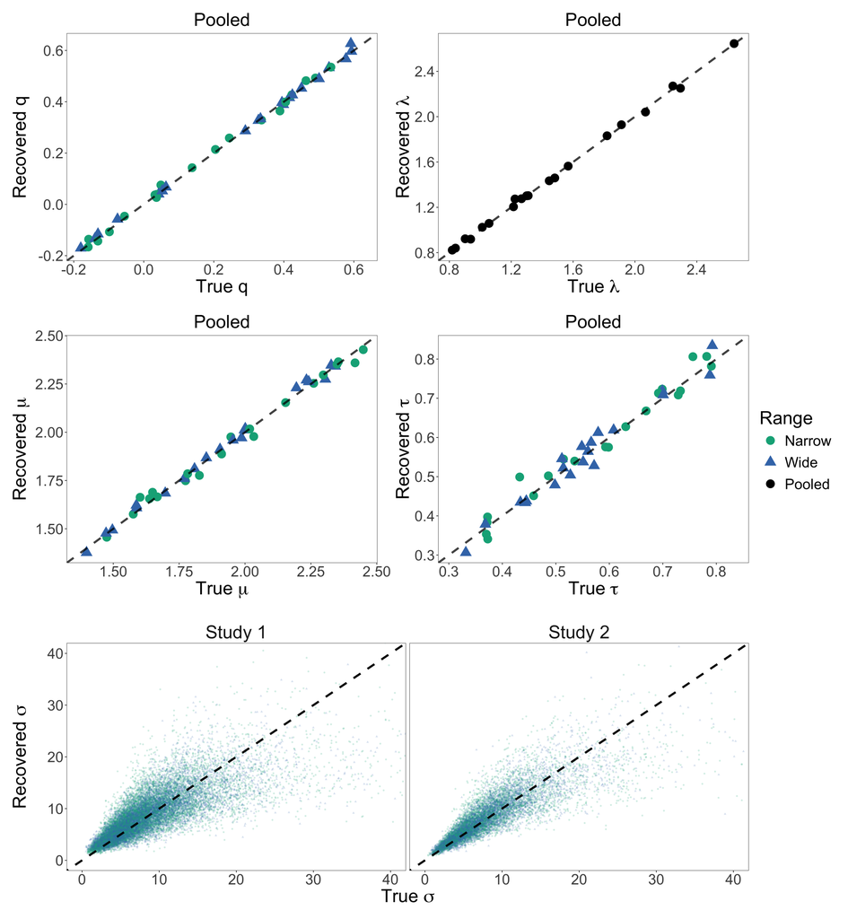

```r
recovery_file <- file.path(cache_dir, "parameter_recovery.rds")
if (!file.exists(recovery_file)) {
  cat("No parameter-recovery cache. Run: Rscript code/parameter_recovery/recover_bayesian_attributes.R\n")
} else {
  rec <- readRDS(recovery_file)
  sig_df <- tibble(); grp_df <- tibble()
  for (r in rec) { sig_df <- bind_rows(sig_df, r$sigma); grp_df <- bind_rows(grp_df, r$group) }
  cat("datasets:", length(rec), "\n")
  for (s in 1:2) {
    x <- sig_df %>% filter(Study == s)
    cat(sprintf("sigma, Study %d: r(log) = %.3f, median |relative error| = %.3f\n", s,
                cor(log(x$true), log(x$recovered)), median(abs(x$recovered - x$true) / x$true)))
  }
  cat(sprintf("q:  r = %.3f, median |recovered - true| = %.3f\n",
              cor(grp_df$true_q, grp_df$rec_q), median(abs(grp_df$rec_q - grp_df$true_q))))
  lam_df <- grp_df %>% filter(WN == "Narrow")   # lambda is shared: one point per dataset
  cat(sprintf("lambda: r(log) = %.3f, median |log(recovered / true)| = %.3f\n",
              cor(log(lam_df$true_lambda), log(lam_df$rec_lambda)), median(abs(log(lam_df$rec_lambda / lam_df$true_lambda)))))
  cat(sprintf("mu:  r = %.3f, median |recovered - true| = %.3f\n",
              cor(grp_df$true_mu, grp_df$rec_mu), median(abs(grp_df$rec_mu - grp_df$true_mu))))
  cat(sprintf("tau: r = %.3f, median |recovered - true| = %.3f\n",
              cor(grp_df$true_tau, grp_df$rec_tau), median(abs(grp_df$rec_tau - grp_df$true_tau))))

  # The paper's figure, drawn by code/utilities/plot_parameter_recovery.R and
  # saved to paper/figures by the recovery script.
  print(plot_parameter_recovery(sig_df, grp_df))
}
```

# Fits and cross-validation

Every variant is fit to all trials on the profile likelihood (at every candidate $q$ and $\lambda$, each condition’s population of $\sigma$ is refit by its own Nelder-Mead on the subjects’ grid log-likelihoods; a grid of $q$, then $q$ per range condition and $\lambda$ refined, jointly over both conditions when $\lambda$ is shared), then refit 12 times, fold $k$ leaving out the $k$-th block of five trial positions of every subject (trials numbered in order within subject; a subject whose count is not a multiple of five has a shorter last block, folds 7 to 12 hold out trials of the 60-trial subjects only, and every trial is held out exactly once) and predicting the held-out trials from each subject’s posterior over $\sigma$ given their training trials. Every fold is fit from scratch by the same three stages on the training trials, population included, so nothing from the full fit enters a fold. The zero and flat priors go through the same stages with $q$ fixed at 0.5: a single pass, nothing to refine per condition, and a bounded one-dimensional search over $\lambda$ with the population refit at every candidate. The caches come from `code/fitting/run_bayesian_fits.R`.

```r
runs <- list()
for (name in names(variants)) {
  have_cache <- file.exists(file.path(cache_dir, paste0("fit_", name, ".rds"))) &&
                file.exists(file.path(cache_dir, paste0("loo_", name, ".rds")))
  if (!have_cache && !RUN_FITS) { cat("No cache for", name, "and RUN_FITS is FALSE. Skipping.\n"); next }
  runs[[name]] <- run_variant(name, boxlong, cache_dir, verbose = FALSE)
}
names(runs)
```

```
## [1] "cond_lam"     "cond_lam1"    "type_lam"     "type_lam1"    "cond_lamcond"
## [6] "zero"         "flat"
```

Convergence: Nelder-Mead stops when the relative spread of the objective over the simplex falls below $10^{-7}$ (code 0) or at the cap on function evaluations (code 1). The full fit’s code(s) and the number of folds with a nonzero code, per variant; the variants with no outer Nelder-Mead call (only one-dimensional bounded searches) show “none”. The inner columns are the same for the population steps (relative tolerance $10^{-10}$, cap 500), the worst code over every population step of the fit or fold.

```r
conv <- tibble()
for (name in names(runs)) {
  f  <- runs[[name]]$fit
  fp <- runs[[name]]$loo$fold_params
  conv <- bind_rows(conv, tibble(
    variant = name,
    full_fit = if (length(f$convergence) > 0) paste(f$convergence, collapse = " ") else "none",
    full_fit_inner = f$convergence_inner,
    folds = n_distinct(fp$fold),
    folds_not_converged = n_distinct(fp$fold[fp$convergence != 0]),
    folds_inner_not_converged = n_distinct(fp$fold[fp$convergence_inner != 0])
  ))
}
as.data.frame(conv)
```

```
##        variant full_fit full_fit_inner folds folds_not_converged
## 1     cond_lam        0              0    12                   0
## 2    cond_lam1     none              0    12                   0
## 3     type_lam        0              0    12                   0
## 4    type_lam1     none              0    12                   0
## 5 cond_lamcond      0 0              0    12                   0
## 6         zero     none              0    12                   0
## 7         flat     none              0    12                   0
##   folds_inner_not_converged
## 1                         0
## 2                         0
## 3                         0
## 4                         0
## 5                         0
## 6                         0
## 7                         0
```

## Parameters

```r
# One row per variant and range condition: the group parameters, the
# population of sigma (exp(mu) is the population median of sigma in points per
# second, tau the SD of log sigma) and the marginal NLL.
params <- tibble()
for (name in names(runs)) {
  f <- runs[[name]]$fit
  params <- bind_rows(params, tibble(
    variant = name, label = variants[[name]]$label, range = names(f$s0),
    s0 = unname(f$s0), q = unname(f$q[names(f$s0)]), lambda = unname(f$lambda[names(f$s0)]),
    sigma_pop = unname(exp(f$mu[names(f$s0)])), tau = unname(f$tau[names(f$s0)]), nll = f$nll
  ))
}
# The reference in points: the prior reference's minimum plus q times its range.
ref_pts <- tibble()
for (name in names(runs)) {
  v <- variants[[name]]
  if (v$prior != "fitted") next
  rd <- reference_distributions(boxlong, v$prior_ref) %>% distinct(WN, type, min, max)
  f  <- runs[[name]]$fit
  ref_pts <- bind_rows(ref_pts, rd %>% mutate(variant = name, q = unname(f$q[as.character(WN)]), reference = min + q * (max - min)) %>%
                         select(variant, WN, type, reference))
}
params %>% mutate(across(where(is.numeric), \(x) round(x, 3))) %>% as.data.frame()
```

```
##         variant                                        label  range   s0     q
## 1      cond_lam           Per-condition prior, loss aversion Narrow    1 0.217
## 2      cond_lam           Per-condition prior, loss aversion   Wide    1 0.187
## 3     cond_lam1                          Per-condition prior Narrow    1 0.230
## 4     cond_lam1                          Per-condition prior   Wide    1 0.219
## 5      type_lam                Per-type prior, loss aversion Narrow    1 0.169
## 6      type_lam                Per-type prior, loss aversion   Wide    1 0.146
## 7     type_lam1                               Per-type prior Narrow    1 0.196
## 8     type_lam1                               Per-type prior   Wide    1 0.156
## 9  cond_lamcond Per-condition prior, loss aversion per range Narrow    1 0.196
## 10 cond_lamcond Per-condition prior, loss aversion per range   Wide    1 0.219
## 11         zero                    Zero prior, loss aversion Narrow    1 0.500
## 12         zero                    Zero prior, loss aversion   Wide    1 0.500
## 13         flat                    Flat prior, loss aversion Narrow 1000 0.500
## 14         flat                    Flat prior, loss aversion   Wide 1000 0.500
##    lambda sigma_pop   tau      nll
## 1   1.063     5.944 0.494 29875.80
## 2   1.063     8.782 0.492 29875.80
## 3   1.000     6.003 0.500 29888.77
## 4   1.000     8.761 0.493 29888.77
## 5   1.122     6.018 0.504 30116.98
## 6   1.122     8.760 0.496 30116.98
## 7   1.000     6.078 0.512 30128.02
## 8   1.000     8.871 0.499 30128.02
## 9   1.121     5.911 0.490 29864.83
## 10  1.001     8.762 0.493 29864.83
## 11  0.947     5.848 0.510 30212.66
## 12  0.947     8.558 0.497 30212.66
## 13  0.951     5.794 0.511 30319.44
## 14  0.951     8.526 0.502 30319.44
```

```r
ref_pts %>% pivot_wider(names_from = type, values_from = reference) %>% mutate(across(where(is.numeric), \(x) round(x, 1))) %>% as.data.frame()
```

```
##         variant     WN     P     N     B
## 1      cond_lam Narrow -17.0 -17.0 -17.0
## 2      cond_lam   Wide -31.3 -31.3 -31.3
## 3     cond_lam1 Narrow -16.2 -16.2 -16.2
## 4     cond_lam1   Wide -28.1 -28.1 -28.1
## 5      type_lam Narrow   9.2 -25.8  -9.9
## 6      type_lam   Wide  11.6 -43.4 -14.2
## 7     type_lam1 Narrow   9.9 -25.1  -9.1
## 8     type_lam1   Wide  12.0 -43.0 -13.8
## 9  cond_lamcond Narrow -18.2 -18.2 -18.2
## 10 cond_lamcond   Wide -28.1 -28.1 -28.1
```

## Out-of-sample log-likelihood

Held-out log-likelihood per model: the sum over every trial of the log probability the model gave to the choice that was made, from a fit that did not see that trial. Differences from the main model (`cond_lam`) are summarised across subjects (one number per subject = that subject’s summed difference).

```r
loo_ll <- tibble()
for (name in names(runs)) {
  p <- runs[[name]]$loo$pred
  loo_ll <- bind_rows(loo_ll, tibble(variant = name, Study = p$Study, Subject = p$Subject, WN = p$WN,
                                     Trial = p$Trial, ChooseL = p$ChooseL, ll = heldout_loglik(p)))
}
loo_total <- loo_ll %>% group_by(variant) %>%
  summarise(total_ll = sum(ll), per_trial = mean(ll), n_trials = n(), .groups = "drop")
loo_cells <- loo_ll %>% group_by(variant, Study, WN) %>%
  summarise(per_trial = mean(ll), .groups = "drop") %>%
  pivot_wider(names_from = c(Study, WN), values_from = per_trial, names_prefix = "S")

subj_ll <- loo_ll %>% group_by(variant, Subject) %>% summarise(ll = sum(ll), .groups = "drop")
ref_ll  <- subj_ll %>% filter(variant == "cond_lam") %>% select(Subject, ll_ref = ll)
loo_diff <- subj_ll %>% left_join(ref_ll, by = "Subject") %>% mutate(d = ll - ll_ref) %>%
  group_by(variant) %>%
  summarise(diff_total = sum(d), diff_mean = mean(d), diff_se = sd(d) / sqrt(n()), .groups = "drop")

loo_table <- loo_total %>% left_join(loo_cells, by = "variant") %>% left_join(loo_diff, by = "variant") %>%
  mutate(label = sapply(variant, function(v) variants[[v]]$label)) %>%
  relocate(label, .after = variant)
loo_table %>% mutate(across(where(is.numeric), \(x) round(x, 4))) %>% as.data.frame()
```

```
##        variant                                        label  total_ll per_trial
## 1     cond_lam           Per-condition prior, loss aversion -29942.94   -0.5152
## 2    cond_lam1                          Per-condition prior -29963.00   -0.5155
## 3 cond_lamcond Per-condition prior, loss aversion per range -29931.32   -0.5150
## 4         flat                    Flat prior, loss aversion -30376.50   -0.5226
## 5     type_lam                Per-type prior, loss aversion -30183.75   -0.5193
## 6    type_lam1                               Per-type prior -30196.79   -0.5195
## 7         zero                    Zero prior, loss aversion -30270.20   -0.5208
##   n_trials S1_Narrow S1_Wide S2_Narrow S2_Wide diff_total diff_mean diff_se
## 1    58122   -0.5268 -0.4988   -0.5201 -0.5145     0.0000    0.0000  0.0000
## 2    58122   -0.5278 -0.4981   -0.5208 -0.5147   -20.0664   -0.0133  0.0074
## 3    58122   -0.5264 -0.4982   -0.5198 -0.5148    11.6141    0.0077  0.0064
## 4    58122   -0.5329 -0.5027   -0.5282 -0.5258  -433.5630   -0.2879  0.0472
## 5    58122   -0.5336 -0.4982   -0.5275 -0.5171  -240.8170   -0.1599  0.0311
## 6    58122   -0.5339 -0.4985   -0.5274 -0.5176  -253.8539   -0.1686  0.0321
## 7    58122   -0.5307 -0.5011   -0.5271 -0.5234  -327.2656   -0.2173  0.0392
```

# Out-of-sample attention weights

```r
plotted <- c("cond_lam", "cond_lam1", "type_lam", "zero", "flat")   # the variants in the paper

# The cluster fits of one variant: every replicate's compact file, per range
# condition -> one weights table in the layout of weights_data. The
# replicates' posteriors are pooled by stacking their draws (the average of
# the posteriors): estimate = median and lo / hi = 95% HDI of the pooled
# draws; se = their SD / sqrt(replicates), the standard error of the average
# over independent replicates. NULL when a range has no file.
sim_draws_files <- function(name, rng) {
  list.files(fit_dir, full.names = TRUE,
             pattern = paste0("^attention_weights_utility_sim_", name, "_", tolower(rng), "_rep[0-9]+_draws\\.rds$"))
}
read_sim_weights <- function(name) {
  weights <- tibble()
  for (rng in c("Narrow", "Wide")) {
    files <- sim_draws_files(name, rng)
    if (length(files) == 0) { cat("No cluster fit for", name, rng, "\n"); return(NULL) }
    draws <- bind_rows(lapply(files, function(f) as_tibble(readRDS(f)$draws) %>% select(matches("^b_"))))
    cells <- names(draws) %>% str_subset("^b_[PNB]_(neg|pos)[0-9]+$") %>% str_remove("^b_")
    for (cell in cells) {
      x <- draws[[paste0("b_", cell)]]
      h <- bayestestR::hdi(x, ci = 0.95)
      weights <- bind_rows(weights, tibble(
        WN = rng, term = cell, reps = length(files), estimate = median(x), se = sd(x) / sqrt(length(files)),
        lo = h$CI_low, hi = h$CI_high
      ))
    }
  }
  weights %>% mutate(
    type  = factor(str_sub(term, 1, 1), levels = c("N", "B", "P")),
    value = as.numeric(str_extract(term, "[0-9]+$")) * if_else(str_detect(term, "_neg"), -1, 1),
    WN    = factor(WN, levels = c("Narrow", "Wide"))
  )
}

weights_model <- list()   # main-text specification, pooled, brms on the cluster: the figures and the fits table
slopes_model  <- list()   # linear value channels, by study, plain regression on ten simulated choices: the slopes chunk
for (name in plotted) {
  weights_model[[name]] <- read_sim_weights(name)
  if (is.null(runs[[name]])) next
  tr <- runs[[name]]$loo$pred %>% transmute(Subject, Trial, WN, Study, p_left = p_left_heldout)
  slopes_model[[name]]  <- simulated_weights(tr, reps = 10, seed = 1)$slopes
}

# Sampler diagnostics of the cluster fits: replicates back per variant and
# range, hours per fit, and the worst diagnostics over the replicates.
sim_diag <- tibble()
for (name in plotted) for (rng in c("Narrow", "Wide")) {
  files <- sim_draws_files(name, rng)
  if (length(files) == 0) next
  d <- bind_rows(lapply(files, function(f) {
    x <- readRDS(f)
    tibble(hours = x$elapsed_hours, divergent = x$n_divergent, treedepth = x$n_max_treedepth,
           max_rhat = max(x$summary$rhat), min_ess_bulk = min(x$summary$ess_bulk))
  }))
  sim_diag <- bind_rows(sim_diag, tibble(
    variant = name, range = rng, reps = nrow(d), hours_mean = round(mean(d$hours), 1),
    divergent = sum(d$divergent), treedepth = sum(d$treedepth),
    max_rhat = round(max(d$max_rhat), 3), min_ess_bulk = round(min(d$min_ess_bulk))
  ))
}
as.data.frame(sim_diag)
```

```
##      variant  range reps hours_mean divergent treedepth max_rhat min_ess_bulk
## 1   cond_lam Narrow   10        3.5         0         0    1.005         1142
## 2   cond_lam   Wide   10        3.7         0         0    1.007         1362
## 3  cond_lam1 Narrow   10        3.7         0         0    1.005         1327
## 4  cond_lam1   Wide   10        4.0         0         0    1.004         1391
## 5   type_lam Narrow   10        4.0         0         0    1.005         1389
## 6   type_lam   Wide   10        3.6         0         0    1.006         1084
## 7       zero Narrow   10        3.6         0         0    1.005         1197
## 8       zero   Wide   10        3.8         0         0    1.005         1146
## 9       flat Narrow   10        3.9         0         0    1.005         1207
## 10      flat   Wide   10        3.8         0         0    1.007         1213
```

```r
# The data through the same regressions.
weights_data_glm <- utility_weight_glm(boxlong %>% mutate(TrialKey = Trial), pas %>% mutate(TrialKey = Trial))
sw_data          <- cell_weight_glm(boxlong %>% mutate(TrialKey = Trial), pas %>% mutate(TrialKey = Trial))
```

## Main figure: data and the best model

The paper gets two figures: this one (the data and the per-condition prior with loss aversion) and one supplementary figure (the per-condition prior without loss aversion, the per-type prior with loss aversion, the zero prior, the flat prior). Each panel overlays the data’s weights (points with 95% intervals) and one model’s weights (lines). This one is only drawn here: the paper’s copy is `attribute_level_attention.pdf`, which `Main_Analysis.Rmd` draws from the same cluster fit. The other comparisons below are shown here but not saved.

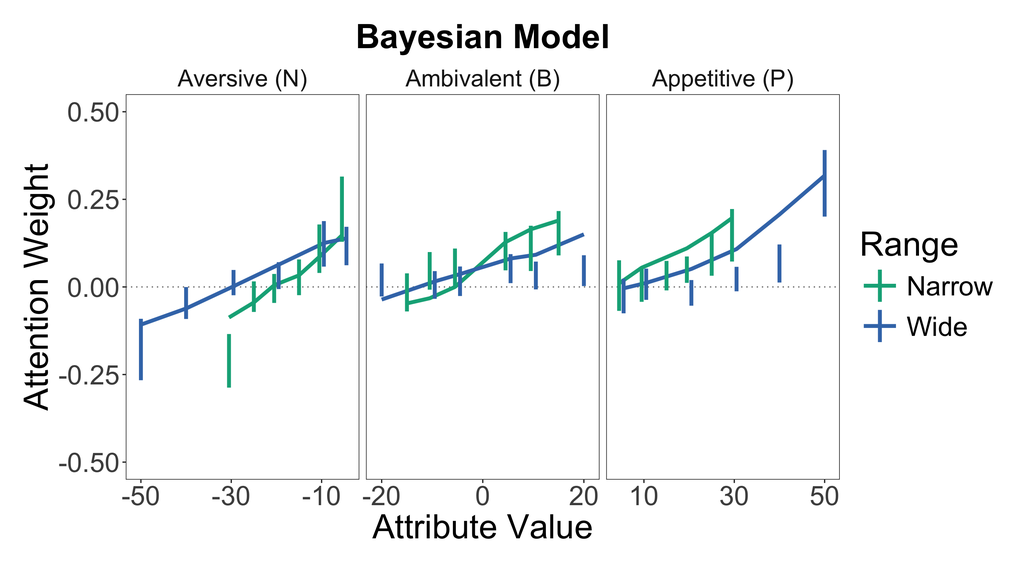

```r
# One panel per model, each overlaying the data's weights (points, 95% CIs)
# and that model's weights (lines). `models` is a named list of weight tables;
# the names are the panel titles. With a `name`, saved under that name in
# paper/figures and notebooks/notebook_figures; without one, only drawn.
overlay_figure <- function(models, name = NULL, ncol = 2, data_w = weights_data, ylim = c(-0.5, 0.5)) {
  panels <- list()
  for (title in names(models)) {
    w <- models[[title]]
    panels[[title]] <- if (is.null(w) || nrow(w) == 0) plot_spacer() else plot_overlay(data_w, w, title, ylim)
  }
  nrow <- ceiling(length(panels) / ncol)
  fig  <- wrap_plots(panels, ncol = ncol) + plot_layout(guides = "collect")
  if (!is.null(name)) {
    ggsave(file.path(fig_dir,    paste0(name, ".pdf")), fig, width = ncol * .figw, height = nrow * .figh)
    ggsave(file.path(nb_fig_dir, paste0(name, ".pdf")), fig, width = ncol * .figw, height = nrow * .figh)
  }
  fig
}

overlay_figure(list("Bayesian Model" = weights_model$cond_lam), ncol = 1)
```

## Supplementary figure: per-condition prior without loss aversion, per-type prior, zero prior, flat prior

Four panels, each with the data’s weights and one variant’s. The first is the main model with $\lambda = 1$: without loss aversion the weights at the lowest aversive values should dip less far below zero than the data’s (the table after the figure gives the numbers). The other three have $\lambda$ fitted.

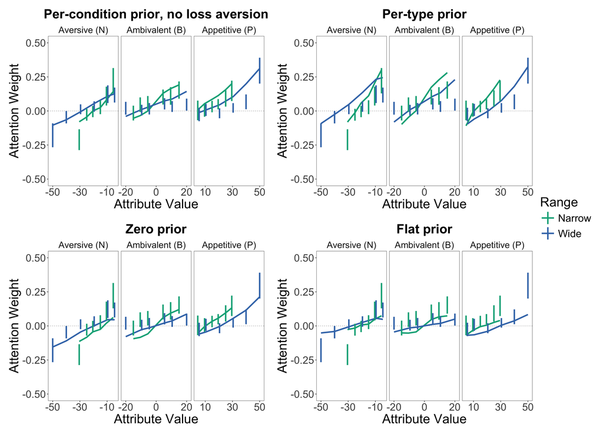

```r
overlay_figure(list("Per-condition prior, no loss aversion" = weights_model$cond_lam1,
                    "Per-type prior" = weights_model$type_lam,
                    "Zero prior" = weights_model$zero,
                    "Flat prior" = weights_model$flat),
               name = "bayesian_model_supp")
```

```r
# Attention weight at the lowest aversive value of each range condition
# (Narrow -30, Wide -50) for the data (brms, and a plain regression for
# comparison), the main model and the main model without loss aversion: the
# comparison the supplementary figure's first panel is for.
dip_rows <- list("Data (brms)"                     = weights_data,
                 "Data (glm)"                      = weights_data_glm,
                 "Per-condition prior"             = weights_model$cond_lam,
                 "Per-condition prior, lambda = 1" = weights_model$cond_lam1)
dip <- tibble()
for (nm in names(dip_rows)) {
  w <- dip_rows[[nm]]
  if (is.null(w) || nrow(w) == 0) next
  lowest <- w %>% filter(type == "N") %>%
    group_by(WN) %>% slice_min(value, n = 1, with_ties = FALSE) %>% ungroup()
  dip <- bind_rows(dip, lowest %>% transmute(source = nm, WN, value, estimate, lo, hi))
}

# One weight from the table, formatted (for the notes).
dip_at <- function(src, rng) {
  x <- dip %>% filter(source == src, WN == rng)
  if (nrow(x) == 0) "NA" else sprintf("%.2f", x$estimate)
}
dip %>% arrange(WN, source) %>% mutate(across(c(estimate, lo, hi), \(x) round(x, 3))) %>% as.data.frame()
```

```
##                            source     WN value estimate     lo     hi
## 1                     Data (brms) Narrow   -30   -0.211 -0.287 -0.134
## 2                      Data (glm) Narrow   -30   -0.041 -0.071 -0.012
## 3             Per-condition prior Narrow   -30   -0.087 -0.143 -0.038
## 4 Per-condition prior, lambda = 1 Narrow   -30   -0.079 -0.139 -0.034
## 5                     Data (brms)   Wide   -50   -0.178 -0.266 -0.091
## 6                      Data (glm)   Wide   -50   -0.015 -0.048  0.017
## 7             Per-condition prior   Wide   -50   -0.108 -0.166 -0.048
## 8 Per-condition prior, lambda = 1   Wide   -50   -0.104 -0.170 -0.045
```

## Crossovers and value slopes

Where each type’s weights cross zero (fraction of the type’s range), and the value slopes (log-odds per 10 points) with their Wide / Narrow ratio. Every variant reproduces a drop from Narrow to Wide through the fitted per-subject noise, so the ratio itself does not separate them. What does is the weighting of B against P and N within a condition: per-type units predict a B/P slope ratio of 0.79 in Narrow and 1.20 in Wide, points predict 1 in both.

```r
# Crossovers (main-text specification, pooled over studies): the data (brms,
# and through a plain regression for comparison) and every model (brms on its
# held-out simulated choices).
cross <- crossover_table(weights_data, "Data (brms)")
cross <- bind_rows(cross, crossover_table(weights_data_glm, "Data (glm)"))
for (name in names(weights_model)) cross <- bind_rows(cross, crossover_table(weights_model[[name]], variants[[name]]$label))
cross_wide <- cross %>% pivot_wider(names_from = c(WN), values_from = crossover) %>% arrange(type, source)
as.data.frame(cross_wide)
```

```
##                                source type Narrow Wide
## 1                         Data (brms)    B   0.04 all+
## 2                          Data (glm)    B   0.03 all+
## 3           Flat prior, loss aversion    B   0.50 0.48
## 4                 Per-condition prior    B   0.33 0.20
## 5  Per-condition prior, loss aversion    B   0.33 0.17
## 6       Per-type prior, loss aversion    B   0.33 0.22
## 7           Zero prior, loss aversion    B   0.50 0.47
## 8                         Data (brms)    N   0.44 0.40
## 9                          Data (glm)    N   0.18 0.42
## 10          Flat prior, loss aversion    N   0.34 0.49
## 11                Per-condition prior    N   0.40 0.47
## 12 Per-condition prior, loss aversion    N   0.38 0.44
## 13      Per-type prior, loss aversion    N   0.24 0.30
## 14          Zero prior, loss aversion    N   0.71 0.66
## 15                        Data (brms)    P   all+ 0.08
## 16                         Data (glm)    P   all+ 0.01
## 17          Flat prior, loss aversion    P   0.50 0.53
## 18                Per-condition prior    P   all+ 0.07
## 19 Per-condition prior, loss aversion    P   all+ 0.03
## 20      Per-type prior, loss aversion    P   0.23 0.34
## 21          Zero prior, loss aversion    P   0.22 0.35
```

```r
# Value slopes (linear value channels, by study): data and every model through
# the same plain regression. The pooled crossovers are attached to both studies'
# rows.
slope_tbl <- sw_data$slopes %>% mutate(source = "Data (glm)")
for (name in names(slopes_model)) slope_tbl <- bind_rows(slope_tbl, slopes_model[[name]] %>% mutate(source = variants[[name]]$label))
slope_wide <- slope_tbl %>% select(source, Study, type, WN, estimate) %>%
  pivot_wider(names_from = WN, values_from = estimate) %>%
  mutate(ratio = Wide / Narrow) %>%
  left_join(cross_wide %>% rename(cross_Narrow = Narrow, cross_Wide = Wide), by = c("source", "type")) %>%
  arrange(Study, type, source)
slope_wide %>% mutate(across(where(is.numeric), \(x) round(x, 3))) %>% as.data.frame()
```

```
##                                source Study type Narrow  Wide ratio
## 1                          Data (glm)     1    B  1.511 1.136 0.752
## 2           Flat prior, loss aversion     1    B  1.315 0.945 0.719
## 3                 Per-condition prior     1    B  1.274 0.933 0.732
## 4  Per-condition prior, loss aversion     1    B  1.273 0.922 0.724
## 5       Per-type prior, loss aversion     1    B  1.345 0.866 0.644
## 6           Zero prior, loss aversion     1    B  1.294 0.944 0.729
## 7                          Data (glm)     1    N  1.609 1.031 0.641
## 8           Flat prior, loss aversion     1    N  1.308 0.915 0.700
## 9                 Per-condition prior     1    N  1.280 0.904 0.706
## 10 Per-condition prior, loss aversion     1    N  1.315 0.912 0.694
## 11      Per-type prior, loss aversion     1    N  1.192 0.914 0.767
## 12          Zero prior, loss aversion     1    N  1.278 0.896 0.701
## 13                         Data (glm)     1    P  1.805 1.109 0.615
## 14          Flat prior, loss aversion     1    P  1.360 0.944 0.695
```

[output cut: 59 more lines]

## Tables

Bare booktabs tabulars for the paper (one per table, `\input` them into a table environment).

```r
save_kable <- function(df, name, digits = 3) {
  tex <- kable(df, format = "latex", booktabs = TRUE, digits = digits, linesep = "")
  writeLines(as.character(tex), file.path(tab_dir, paste0(name, ".tex")))
  cat(as.character(tex), "\n")
}

# The paper's table of estimates: the main model, the main model without loss
# aversion, the per-type prior, the zero prior and the flat prior (all with
# loss aversion unless the title says otherwise), under the titles used in the
# paper (the second title is two lines).
fits_titles <- c(cond_lam  = "Per-Condition Prior",
                 cond_lam1 = "\\shortstack[l]{Per-Condition Prior\\\\No Loss Aversion}",
                 type_lam  = "Per-Type Prior",
                 zero      = "Zero Prior",
                 flat      = "Flat Prior")
fits_ll <- setNames(loo_table$total_ll, loo_table$variant)

# Difference in out-of-sample log-likelihood from the main model: the mean
# across participants, with the p-value of a paired t-test across participants
# (two-sided; each participant's log-likelihood under the variant against
# under the main model). The p-value is written as a bare number, formatted
# like fmt_p in the main notebook: three decimals, or scientific notation below
# .001 (the column header says it is the p-value). "--" for the main model
# itself.
fmt_delta_p <- function(name) {
  if (name == "cond_lam") return("--")
  x  <- subj_ll %>% filter(variant %in% c(name, "cond_lam")) %>% pivot_wider(names_from = variant, values_from = ll)
  p  <- t.test(x[[name]], x[["cond_lam"]], paired = TRUE)$p.value
  p_txt <- if (p < 0.001) formatC(p, format = "e", digits = 0) else sprintf("%.3f", p)
  sprintf("%.2f (%s)", mean(x[[name]] - x[["cond_lam"]]), p_txt)
}

# Prior variance in points^2 of one variant in one range condition: the prior
# SD is s0 times the SD of the reference distribution (box_prior_sd in the
# model code), squared. The per-condition reference has one SD; the per-type
# reference has one per attribute type, returned named, in the order N, B, P.
prior_variance <- function(name, rng) {
  ref <- reference_distributions(boxlong, variants[[name]]$prior_ref) %>% filter(WN == rng)
  ref <- ref[match(c("N", "B", "P"), as.character(ref$type)), ]
  v   <- setNames((runs[[name]]$fit$s0[[rng]] * ref$sd)^2, c("N", "B", "P"))
  if (variants[[name]]$prior_ref == "cond") v <- unname(v[1])
  v
}

# Variances as one string for a table cell, rounded to whole points^2: "309",
# or, for the per-type prior, "88, 140": the variance of the negative and
# positive types (NP),
# then that of the ambivalent type (B). Negative and positive values mirror
# each other, so their variances are equal (checked). Numbers of a hundred
# thousand or more (the flat prior) go in powers of ten.
fmt_variance <- function(v) {
  txt <- c()
  for (x in v) {
    if (x < 1e5) {
      txt <- c(txt, sprintf("%.0f", x))
    } else {
      e   <- floor(log10(x))
      txt <- c(txt, sprintf("$%.1f \\times 10^{%d}$", x / 10^e, e))
    }
  }
  if (is.null(names(v))) return(txt)
  stopifnot(isTRUE(all.equal(v[["N"]], v[["P"]])))
  paste(txt[names(v) == "N"], txt[names(v) == "B"], sep = ", ")
}

# Attention-weight error of a variant: the mean, over the 36 cells (18 per
# range condition), of the absolute difference between the weight estimated
# from the variant's out-of-sample simulated choices (the same brms model as
# the data's, on the cluster) and the data's weight (the paper's brms fit). Its noise
# floor is the error a variant that predicted the data's true weights would
# still show, because both estimates carry sampling error: per cell, the
# expected absolute value of a normal variable with variance SE_data^2 +
# SE_sim^2 (the data's posterior SD; the SD of the variant's pooled replicate
# draws over sqrt(replicates)), sqrt(2 / pi) * sqrt(SE_data^2 + SE_sim^2),
# averaged over the cells.
attn_error <- function(name) {
  x <- weights_model[[name]] %>% select(WN, term, est_sim = estimate, se_sim = se) %>%
    inner_join(weights_data %>% select(WN, term, est_data = estimate, se_data = se), by = c("WN", "term"))
  stopifnot(nrow(x) == 36)
  c(mae = mean(abs(x$est_sim - x$est_data)), floor = mean(sqrt(2 / pi) * sqrt(x$se_data^2 + x$se_sim^2)))
}
attn_errors <- sapply(names(fits_titles), attn_error)   # rows mae / floor, one column per variant
floors      <- attn_errors["floor", ]
floor_txt   <- if (max(floors) - min(floors) < 0.0005) sprintf("%.3f", mean(floors)) else
  sprintf("between %.3f and %.3f", min(floors), max(floors))
print(round(attn_errors, 4)); cat("noise floor (not in the table note):", floor_txt, "\n")
```

```
##       cond_lam cond_lam1 type_lam   zero   flat
## mae     0.0445    0.0436   0.0744 0.0504 0.0568
## floor   0.0231    0.0231   0.0234 0.0230 0.0228
```

```
## noise floor (not in the table note): between 0.023 and 0.023
```

```r
# The tabular is written by hand: every model gets two rows (Narrow, Wide),
# with its title, lambda, out-of-sample log-likelihood and its difference from
# the main model spanning both rows (\multirow), and a rule between models. The
# column padding is narrowed inside a group so that the ten columns fit the
# page; it needs the multirow package in the paper's preamble.
fits_lines <- c("{\\setlength{\\tabcolsep}{3.5pt}%", "\\begin{tabular}{llrrrrrrrr}", "\\toprule",
                paste("Model & Range & $s^2_p (\\text{NP}, \\text{B})$ & $q$ & $\\lambda$ & $\\exp(\\mu)$ & $\\tau$ & OOS-LL &",
                      "\\shortstack[c]{$\\Delta^{\\text{OOS-LL}}_{\\text{Participants}}$\\\\(\\textit{p}-value)} &",
                      "\\shortstack[c]{OOS-MAE\\\\Attn. Weights} \\\\"),
                "\\midrule")
for (name in names(fits_titles)) {
  f <- runs[[name]]$fit
  # One lambda for both ranges in all five models, so one cell can hold it.
  stopifnot(isTRUE(all.equal(f$lambda[["Narrow"]], f$lambda[["Wide"]])))
  for (rng in c("Narrow", "Wide")) {
    first <- rng == "Narrow"
    cells <- c(
      if (first) sprintf("\\multirow{2}{*}{%s}", fits_titles[[name]]) else "",
      rng,
      fmt_variance(prior_variance(name, rng)),
      sprintf("%.2f", f$q[[rng]]),
      if (first) sprintf("\\multirow{2}{*}{%.2f}", f$lambda[[rng]]) else "",
      sprintf("%.2f", exp(f$mu[[rng]])),
      sprintf("%.2f", f$tau[[rng]]),
      if (first) sprintf("\\multirow{2}{*}{%.0f}", fits_ll[[name]]) else "",
      if (first) sprintf("\\multirow{2}{*}{%s}", fmt_delta_p(name)) else "",
      if (first) sprintf("\\multirow{2}{*}{%.3f}", attn_errors["mae", name]) else "")
    fits_lines <- c(fits_lines, paste0(paste(cells, collapse = " & "), " \\\\"))
  }
  if (name != names(fits_titles)[length(fits_titles)]) fits_lines <- c(fits_lines, "\\midrule")
}
# The note spans the text width, in a smaller font, under the table (the same
# layout as the notes of the regression tables).
fits_note <- paste("\\textit{Note.} $s^2_p (\\text{NP}, \\text{B})$ jointly reports the prior variance for negative and positive",
                   "attribute types, since by definition this was the same in these two attribute types. Then, it reports",
                   "the prior variance for ambivalent attribute types, which had a wider range of possible values.",
                   "For $\\Delta^{\\text{OOS-LL}}_{\\text{Participants}}$, we took the out-of-sample log-likelihood of every",
                   "participant for every variant, then compared the difference between a variant's log-likelihood and the",
                   "best model's log-likelihood across all participants (the mean difference per participant, with the",
                   "p-value of a paired t-test across participants in parentheses).",
                   "OOS-MAE Attn. Weights is the mean, over the 36 cells (value $\\times$ attribute type $\\times$ range),",
                   "of the absolute difference between the attentional weight estimated from a variant's out-of-sample",
                   "simulated choices and the data's attentional weight.")
fits_lines <- c(fits_lines, "\\bottomrule", "\\end{tabular}}", "\\par\\medskip",
                paste0("\\begin{minipage}{\\linewidth}\\footnotesize ", fits_note, "\\end{minipage}"))
writeLines(fits_lines, file.path(tab_dir, "bayesian_model_fits.tex"))
cat(fits_lines, sep = "\n")
```

[output not shown]

```r
slopes_out <- slope_wide %>%
  rename(Source = source, Type = type, `Narrow slope` = Narrow, `Wide slope` = Wide, `Wide / Narrow` = ratio,
         `Crossover Narrow` = cross_Narrow, `Crossover Wide` = cross_Wide)
save_kable(slopes_out, "bayesian_model_slopes")
```

```
##
## \begin{tabular}{lrlrrrll}
## \toprule
## Source & Study & Type & Narrow slope & Wide slope & Wide / Narrow & Crossover Narrow & Crossover Wide\\
## \midrule
## Data (glm) & 1 & B & 1.511 & 1.136 & 0.752 & 0.03 & all+\\
## Flat prior, loss aversion & 1 & B & 1.315 & 0.945 & 0.719 & 0.50 & 0.48\\
## Per-condition prior & 1 & B & 1.274 & 0.933 & 0.732 & 0.33 & 0.20\\
## Per-condition prior, loss aversion & 1 & B & 1.273 & 0.922 & 0.724 & 0.33 & 0.17\\
## Per-type prior, loss aversion & 1 & B & 1.345 & 0.866 & 0.644 & 0.33 & 0.22\\
## Zero prior, loss aversion & 1 & B & 1.294 & 0.944 & 0.729 & 0.50 & 0.47\\
## Data (glm) & 1 & N & 1.609 & 1.031 & 0.641 & 0.18 & 0.42\\
## Flat prior, loss aversion & 1 & N & 1.308 & 0.915 & 0.700 & 0.34 & 0.49\\
## Per-condition prior & 1 & N & 1.280 & 0.904 & 0.706 & 0.40 & 0.47\\
## Per-condition prior, loss aversion & 1 & N & 1.315 & 0.912 & 0.694 & 0.38 & 0.44\\
## Per-type prior, loss aversion & 1 & N & 1.192 & 0.914 & 0.767 & 0.24 & 0.30\\
## Zero prior, loss aversion & 1 & N & 1.278 & 0.896 & 0.701 & 0.71 & 0.66\\
## Data (glm) & 1 & P & 1.805 & 1.109 & 0.615 & all+ & 0.01\\
## Flat prior, loss aversion & 1 & P & 1.360 & 0.944 & 0.695 & 0.50 & 0.53\\
## Per-condition prior & 1 & P & 1.301 & 0.888 & 0.683 & all+ & 0.07\\
## Per-condition prior, loss aversion & 1 & P & 1.298 & 0.879 & 0.677 & all+ & 0.03\\
## Per-type prior, loss aversion & 1 & P & 1.221 & 0.904 & 0.740 & 0.23 & 0.34\\
## Zero prior, loss aversion & 1 & P & 1.345 & 0.932 & 0.693 & 0.22 & 0.35\\
## Data (glm) & 2 & B & 1.501 & 1.053 & 0.701 & 0.03 & all+\\
## Flat prior, loss aversion & 2 & B & 1.267 & 0.848 & 0.670 & 0.50 & 0.48\\
## Per-condition prior & 2 & B & 1.207 & 0.836 & 0.693 & 0.33 & 0.20\\
## Per-condition prior, loss aversion & 2 & B & 1.202 & 0.829 & 0.689 & 0.33 & 0.17\\
## Per-type prior, loss aversion & 2 & B & 1.269 & 0.755 & 0.595 & 0.33 & 0.22\\
## Zero prior, loss aversion & 2 & B & 1.239 & 0.839 & 0.677 & 0.50 & 0.47\\
## Data (glm) & 2 & N & 1.521 & 0.951 & 0.626 & 0.18 & 0.42\\
## Flat prior, loss aversion & 2 & N & 1.247 & 0.835 & 0.670 & 0.34 & 0.49\\
## Per-condition prior & 2 & N & 1.196 & 0.818 & 0.684 & 0.40 & 0.47\\
## Per-condition prior, loss aversion & 2 & N & 1.224 & 0.826 & 0.674 & 0.38 & 0.44\\
## Per-type prior, loss aversion & 2 & N & 1.096 & 0.822 & 0.750 & 0.24 & 0.30\\
## Zero prior, loss aversion & 2 & N & 1.195 & 0.807 & 0.676 & 0.71 & 0.66\\
## Data (glm) & 2 & P & 1.724 & 0.984 & 0.571 & all+ & 0.01\\
## Flat prior, loss aversion & 2 & P & 1.321 & 0.867 & 0.656 & 0.50 & 0.53\\
## Per-condition prior & 2 & P & 1.229 & 0.809 & 0.659 & all+ & 0.07\\
## Per-condition prior, loss aversion & 2 & P & 1.224 & 0.802 & 0.655 & all+ & 0.03\\
## Per-type prior, loss aversion & 2 & P & 1.134 & 0.820 & 0.723 & 0.23 & 0.34\\
## Zero prior, loss aversion & 2 & P & 1.284 & 0.849 & 0.661 & 0.22 & 0.35\\
## \bottomrule
## \end{tabular}
```

## Text Output

Statistics quoted in the paper’s model sections, as LaTeX math snippets in `paper/text_output/` (same convention as the main notebook: a study or a between-study contrast goes in the subscript, everything else in the superscript), plus a compact model-comparison table for the paper.

```r
text_dir  <- file.path(paths$root, paths$paper_text)
save_text <- function(text, name) {
  write.text(text, file.path(text_dir, paste0(name, ".tex")))
  cat(name, ": ", text, "\n")
}
fmt_delta <- function(a, b) {
  # Held-out log-likelihood of variant a minus variant b: total, and mean +/- SE per participant.
  x  <- subj_ll %>% filter(variant %in% c(a, b)) %>% pivot_wider(names_from = variant, values_from = ll)
  dd <- x[[a]] - x[[b]]
  sprintf("%.0f\\ (%.2f \\pm %.2f \\text{ per participant})", sum(dd), mean(dd), sd(dd) / sqrt(length(dd)))
}

best <- runs$cond_lam$fit
save_text(sprintf("$q^{\\text{Narrow}} = %.2f$, $q^{\\text{Wide}} = %.2f$, $\\lambda = %.2f$",
                  best$q[["Narrow"]], best$q[["Wide"]], best$lambda[[1]]),
          "bayes_best_params")
```

```
## bayes_best_params :  $q^{\text{Narrow}} = 0.22$, $q^{\text{Wide}} = 0.19$, $\lambda = 1.06$
```

```r
# Slow numbers that depend only on the fitted parameters (the numerical checks
# below, the participants' log-likelihoods on the sigma grid) are kept in
# results/temp, so that a render that only changes a table or a sentence does
# not recompute them. A saved result is used only when the parameters stored
# with it are identical to the current fit's; after changing the model code or
# the grids, delete the .rds file in results/temp to force a recompute.
temp_dir <- file.path(paths$root, paths$results$temp)
dir.create(temp_dir, showWarnings = FALSE, recursive = TRUE)
load_temp <- function(name, par) {
  f <- file.path(temp_dir, paste0(name, ".rds"))
  if (!file.exists(f)) return(NULL)
  x <- readRDS(f)
  if (identical(x$par, par)) x else NULL
}
save_temp <- function(x, name) saveRDS(x, file.path(temp_dir, paste0(name, ".rds")))

# Numerical checks at the fitted parameters of the main model, for the
# supplement: how much the log-likelihood moves when the sigma grid is doubled
# (60 -> 120 points) and when the utility grid's spacing is halved, and how far
# off the normal approximation that the exact calculation replaced was.
fmt_sci  <- function(x) { x <- abs(x); e <- floor(log10(x)); sprintf("$%.1f \\times 10^{%d}$", x / 10^e, e) }
par_best <- list(s0 = best$s0, q = best$q, lambda = best$lambda)
checks   <- load_temp("bayes_numerical_checks", par_best)
if (is.null(checks)) {
  nll_exact  <- profile_total(prep_cond, par_best)
  nll_probit <- profile_total(prep_cond, par_best, exact = FALSE)
  GRID_FACTOR <- 0.25                                      # half the usual spacing (the functions read this at call time)
  nll_fine <- profile_total(prep_cond, par_best)
  GRID_FACTOR <- 0.5
  grid_saved <- list(log = SIGMA_GRID_LOG, grid = SIGMA_GRID, mu = MU_BOUNDS)
  SIGMA_GRID_LOG <- seq(log(0.005), log(500), length.out = 120); SIGMA_GRID <- exp(SIGMA_GRID_LOG); MU_BOUNDS <- range(SIGMA_GRID_LOG)
  nll_sigma <- profile_total(prep_cond, par_best)
  SIGMA_GRID_LOG <- grid_saved$log; SIGMA_GRID <- grid_saved$grid; MU_BOUNDS <- grid_saved$mu
  # The largest difference between the probit and the exact probability on any
  # trial at any sigma of the grid.
  max_err <- 0
  for (s in names(prep_cond$subj)) {
    piece <- prep_cond$subj[[s]]
    sig   <- matrix(SIGMA_GRID, nrow(piece$boxes), length(SIGMA_GRID), byrow = TRUE)
    p_e   <- exp(piece_choice_logprob(piece, variants$cond_lam, sig, par_best)$left)
    p_p   <- exp(piece_choice_logprob(piece, variants$cond_lam, sig, par_best, exact = FALSE)$left)
    max_err <- max(max_err, abs(p_e - p_p))
  }
  checks <- list(par = par_best, nll_exact = nll_exact, nll_probit = nll_probit,
                 nll_fine = nll_fine, nll_sigma = nll_sigma, max_err = max_err)
  save_temp(checks, "bayes_numerical_checks")
}
save_text(fmt_sci(checks$nll_sigma - checks$nll_exact), "bayes_check_sigma_grid")
```

```
## bayes_check_sigma_grid :  $2.0 \times 10^{-5}$
```

```r
save_text(fmt_sci(checks$nll_fine - checks$nll_exact),  "bayes_check_utility_grid")
```

```
## bayes_check_utility_grid :  $2.3 \times 10^{-5}$
```

```r
save_text(sprintf("%.1f", abs(checks$nll_probit - checks$nll_exact)), "bayes_probit_error")
```

```
## bayes_probit_error :  0.7
```

```r
save_text(sprintf("%.3f", checks$max_err), "bayes_probit_max_error")
```

```
## bayes_probit_max_error :  0.007
```

```r
rp <- ref_pts %>% filter(variant == "cond_lam", type == "P")
save_text(sprintf("$%.0f$ points in Narrow and $%.0f$ points in Wide", rp$reference[rp$WN == "Narrow"], rp$reference[rp$WN == "Wide"]), "bayes_best_reference")
```

```
## bayes_best_reference :  $-17$ points in Narrow and $-31$ points in Wide
```

```r
save_text(sprintf("$\\lambda^{\\text{Narrow}} = %.2f$, $\\lambda^{\\text{Wide}} = %.2f$", runs$cond_lamcond$fit$lambda[["Narrow"]], runs$cond_lamcond$fit$lambda[["Wide"]]), "bayes_lambda_by_range")
```

```
## bayes_lambda_by_range :  $\lambda^{\text{Narrow}} = 1.12$, $\lambda^{\text{Wide}} = 1.00$
```

```r
save_text(paste0("$\\Delta^{\\text{loss aversion - none}} = ", fmt_delta("cond_lam", "cond_lam1"), "$"), "bayes_loo_lambda")
```

```
## bayes_loo_lambda :  $\Delta^{\text{loss aversion - none}} = 20\ (0.01 \pm 0.01 \text{ per participant})$
```

```r
save_text(paste0("$\\Delta^{\\text{per-condition - per-type}} = ", fmt_delta("cond_lam", "type_lam"), "$"), "bayes_loo_prior")
```

```
## bayes_loo_prior :  $\Delta^{\text{per-condition - per-type}} = 241\ (0.16 \pm 0.03 \text{ per participant})$
```

```r
save_text(paste0("$\\Delta^{\\text{per-condition - flat}} = ", fmt_delta("cond_lam", "flat"), "$, ",
                 "$\\Delta^{\\text{per-condition - zero}} = ", fmt_delta("cond_lam", "zero"), "$"), "bayes_loo_flat_zero")
```

```
## bayes_loo_flat_zero :  $\Delta^{\text{per-condition - flat}} = 434\ (0.29 \pm 0.05 \text{ per participant})$, $\Delta^{\text{per-condition - zero}} = 327\ (0.22 \pm 0.04 \text{ per participant})$
```

```r
if (exists("grp_df")) {
  # Pearson r between true and recovered values. q, mu and tau on their own
  # scale, over both range conditions; lambda (one point per dataset) and
  # sigma (one point per participant and dataset, by study; the recovered
  # value is the posterior mean) on the log scale, the same scale as the
  # recovery chunk's summary: lambda is drawn log-uniformly and sigma is
  # log-normal across participants, so on the log scale every dataset and
  # participant counts alike instead of the few noisiest participants
  # dominating. The snippet says which values are on the log scale.
  r_sigma <- c()
  for (s in 1:2) {
    x <- sig_df %>% filter(Study == s)
    r_sigma[s] <- cor(log(x$true), log(x$recovered))
  }
  save_text(sprintf("$r^{q} = %.2f$, $r^{\\mu} = %.2f$, $r^{\\tau} = %.2f$, and on the log scale $r^{\\lambda} = %.2f$, $r^{\\sigma}_{\\text{Study 1}} = %.2f$, $r^{\\sigma}_{\\text{Study 2}} = %.2f$",
                    cor(grp_df$true_q, grp_df$rec_q), cor(grp_df$true_mu, grp_df$rec_mu), cor(grp_df$true_tau, grp_df$rec_tau),
                    cor(log(lam_df$true_lambda), log(lam_df$rec_lambda)), r_sigma[1], r_sigma[2]),
            "bayes_recovery")
}
```

```
## bayes_recovery :  $r^{q} = 1.00$, $r^{\mu} = 1.00$, $r^{\tau} = 0.99$, and on the log scale $r^{\lambda} = 1.00$, $r^{\sigma}_{\text{Study 1}} = 0.84$, $r^{\sigma}_{\text{Study 2}} = 0.90$
```

```r
save_text(sprintf("%s", format(prep_cond$n_dropped, big.mark = ",")), "bayes_dropped_trials")
```

```
## bayes_dropped_trials :  1,047
```

```r
# Held-out trials of the main model whose chosen option got a probability below
# the 1e-12 floor applied in heldout_loglik (errors on easy trials).
p_main   <- runs$cond_lam$loo$pred
p_chosen <- ifelse(p_main$ChooseL == 1, p_main$p_left_heldout, 1 - p_main$p_left_heldout)
save_text(sprintf("%d of %s", sum(p_chosen < 1e-12), format(nrow(p_main), big.mark = ",")), "bayes_clipped_trials")
```

```
## bayes_clipped_trials :  0 of 58,122
```

```r
# Compact comparison table for the paper: the four priors with lambda fitted
# plus the main model without loss aversion.
comp <- tibble()
for (name in c("cond_lam", "cond_lam1", "type_lam", "zero", "flat")) {
  f <- runs[[name]]$fit
  x <- subj_ll %>% filter(variant %in% c(name, "cond_lam")) %>% pivot_wider(names_from = variant, values_from = ll)
  dd <- if (name == "cond_lam") rep(0, nrow(x)) else x[[name]] - x[["cond_lam"]]
  comp <- bind_rows(comp, tibble(
    Prior = c(cond_lam = "Per condition", cond_lam1 = "Per condition", type_lam = "Per type", zero = "Zero", flat = "Flat")[[name]],
    `$\\lambda$` = if (f$variant$lambda == "fixed1") "1 (fixed)" else sprintf("%.2f", f$lambda[[1]]),
    `$q$ (N/W)`   = if (f$variant$prior == "fitted") sprintf("%.2f / %.2f", f$q[["Narrow"]], f$q[["Wide"]]) else "--",
    `Out-of-Sample LL` = sprintf("%.0f", sum(loo_ll$ll[loo_ll$variant == name])),
    `$\\Delta$ per subject (SE)` = if (name == "cond_lam") "--" else sprintf("%.2f (%.2f)", mean(dd), sd(dd) / sqrt(length(dd)))
  ))
}
tex <- kable(comp, format = "latex", booktabs = TRUE, escape = FALSE, linesep = "")
writeLines(as.character(tex), file.path(tab_dir, "bayesian_model_comparison.tex"))
cat(as.character(tex), "\n")
```

```
##
## \begin{tabular}{lllll}
## \toprule
## Prior & $\lambda$ & $q$ (N/W) & Out-of-Sample LL & $\Delta$ per subject (SE)\\
## \midrule
## Per condition & 1.06 & 0.22 / 0.19 & -29943 & --\\
## Per condition & 1 (fixed) & 0.23 / 0.22 & -29963 & -0.01 (0.01)\\
## Per type & 1.12 & 0.17 / 0.15 & -30184 & -0.16 (0.03)\\
## Zero & 0.95 & -- & -30270 & -0.22 (0.04)\\
## Flat & 0.95 & -- & -30377 & -0.29 (0.05)\\
## \bottomrule
## \end{tabular}
```

# Sampling noise by range condition

The main text says that sampling noise per second is lower in the Narrow condition than in the Wide condition. The fitted populations put the median $\sigma$, $\exp(\mu)$, at 5.9 points per second in Narrow and 8.8 in Wide, but the fit gives no standard error for $\mu$ (Nelder-Mead, no Hessian). So the test is a bootstrap over participants: resample the participants of each condition with replacement, refit that condition’s population $(\mu, \tau)$, repeat. This is cheap because, given the fitted $q$ and $\lambda$ of the main model, every participant’s log-likelihood on the $\sigma$ grid is one grid pass (`grid_pass`, about two minutes) and a condition’s population step is a Nelder-Mead on its participants’ rows of that matrix (`fit_population`, a few hundredths of a second per replicate). $q$ and $\lambda$ stay at their fitted values, so the interval leaves out their (small) uncertainty.

The statistic for the paper is the difference in the population median of $\sigma$, $\exp(\mu^{\text{Wide}}) - \exp(\mu^{\text{Narrow}})$ in points per second: the point estimate from the full fit, the 95% interval from the bootstrap percentiles. Participants are in one range condition each, so the two conditions are resampled independently. This is deliberately not a t-test on the participants’ posterior-mean $\sigma$’s: those are shrunk toward their own condition’s population, so a test on them partly restates the difference in $\mu$. (`save_text` and `load_temp` come from the Text Output chunk above.)

```r
set.seed(1)
B <- 1000

# Every participant's log-likelihood on the sigma grid at the fitted group
# parameters of the main model (participants x grid).
fit_main <- runs$cond_lam$fit
par_main <- list(s0 = fit_main$s0, q = fit_main$q, lambda = fit_main$lambda)
cached   <- load_temp("bayes_sigma_grid_ll", par_main)   # ~100 s to compute (see load_temp)
if (is.null(cached)) {
  ll_main <- grid_pass(prep_cond, par_main)
  save_temp(list(par = par_main, ll_main = ll_main), "bayes_sigma_grid_ll")
} else {
  ll_main <- cached$ll_main
}

# Check: the population step on these rows reproduces the cached fit.
for (cc in c("Narrow", "Wide")) {
  pop <- fit_population(ll_main[prep_cond$subjects$Subject[prep_cond$subjects$WN == cc], , drop = FALSE])
  cat(sprintf("%s: mu = %.4f (fit %.4f), tau = %.4f (fit %.4f)\n", cc, pop$mu, fit_main$mu[[cc]], pop$tau, fit_main$tau[[cc]]))
}
```

```
## Narrow: mu = 1.7824 (fit 1.7824), tau = 0.4942 (fit 0.4942)
## Wide: mu = 2.1727 (fit 2.1727), tau = 0.4924 (fit 0.4924)
```

```r
# Bootstrap: resample participants within each condition and refit (mu, tau).
subs     <- split(prep_cond$subjects$Subject, prep_cond$subjects$WN)
boot     <- tibble()
not_conv <- 0
for (b in 1:B) {
  row <- c()
  for (cc in names(subs)) {
    s   <- sample(subs[[cc]], replace = TRUE)
    pop <- fit_population(ll_main[s, , drop = FALSE])
    not_conv <- not_conv + (pop$convergence != 0)
    row[paste0("mu_", cc)]  <- pop$mu
    row[paste0("tau_", cc)] <- pop$tau
  }
  boot <- bind_rows(boot, as_tibble_row(row))
}
cat("population steps not converged:", not_conv, "of", 2 * B, "\n")
```

```
## population steps not converged: 0 of 2000
```

```r
# Difference in the population median sigma (points per second), Wide minus
# Narrow: point estimate from the full fit, 95% percentile interval from the
# bootstrap. The log-scale difference and the bootstrap SDs are printed for
# the record.
boot <- boot %>% mutate(d_median = exp(mu_Wide) - exp(mu_Narrow), d_mu = mu_Wide - mu_Narrow)
est  <- exp(fit_main$mu[["Wide"]]) - exp(fit_main$mu[["Narrow"]])
ci   <- quantile(boot$d_median, c(0.025, 0.975))
cat(sprintf("exp(mu): Narrow %.2f, Wide %.2f; difference %.2f [%.2f, %.2f]; log difference %.3f (bootstrap SD %.3f)\n",
            exp(fit_main$mu[["Narrow"]]), exp(fit_main$mu[["Wide"]]), est, ci[1], ci[2],
            fit_main$mu[["Wide"]] - fit_main$mu[["Narrow"]], sd(boot$d_mu)))
```

```
## exp(mu): Narrow 5.94, Wide 8.78; difference 2.84 [2.37, 3.29]; log difference 0.390 (bootstrap SD 0.032)
```

```r
boot %>% summarise(across(everything(), list(mean = mean, sd = sd))) %>% as.data.frame()
```

```
##   mu_Narrow_mean mu_Narrow_sd tau_Narrow_mean tau_Narrow_sd mu_Wide_mean
## 1       1.780524   0.02325192        0.493482    0.02186308      2.17185
##   mu_Wide_sd tau_Wide_mean tau_Wide_sd d_median_mean d_median_sd d_mu_mean
## 1 0.02223904     0.4920409  0.02145044      2.842104     0.23631 0.3913262
##      d_mu_sd
## 1 0.03177227
```

```r
save_text(sprintf("$\\Delta^{\\text{Wide} - \\text{Narrow}}_{\\exp(\\mu)} = %.2f\\ [%.2f, %.2f]$", est, ci[1], ci[2]),
          "bayes_sigma_range")
```

```
## bayes_sigma_range :  $\Delta^{\text{Wide} - \text{Narrow}}_{\exp(\mu)} = 2.84\ [2.37, 3.29]$
```

# Notes

Fifth run, 2026-10-30/31: exact choice probabilities and 12-fold cross-validation. The probit $\Phi(\Delta / \sqrt{v})$ is exact only at $\lambda = 1$ (each box’s utility is a normal whose lower half is stretched by $\lambda$, so the left-right difference is not normal); it is replaced by the convolution on a grid of utility values (`exact_choice_prob.cpp`: cell width half the smallest box SD, Richardson extrapolation over three spacings), with the probit kept only where it is exact. The 60-fold leave-one-trial-out became 12 folds of five trial positions per subject, since every fold is a full fit of about an hour with the exact probabilities (60 folds would have been about 380 process-hours). The recovery’s cap on stage-3 evaluations rose from 60 to 200, the same as the real data.

**Headline.** The full fits land on the probit optimum to three decimals: $q = 0.22$ / $0.19$, $\lambda = 1.06$, in-sample NLL 29875.8 (the probit was off by 0.7 units in total, at most 0.007 per trial). Held-out NLL over the 58,122 trials: main model 29943; without loss aversion 29963 ($+20$); $\lambda$ per condition 29931 ($-12$; 1.12 Narrow, 1.00 Wide); per-type prior 30184 ($+241$); zero prior 30270 ($+327$); flat prior 30377 ($+434$). These are not comparable to the fourth run’s held-out numbers: with five trials held out, a subject’s posterior over $\sigma$ rests on 55 (or 19 to 25) training trials instead of 59, so every variant predicts a little worse by design; the ranking is unchanged and the gap to the $\lambda = 1$ model is 20 units (34 before). Across the main model’s 12 folds $q$ ranges 0.20 to 0.22 (Narrow) and 0.17 to 0.20 (Wide) and $\lambda$ 1.05 to 1.08. Nelder-Mead stopped on its tolerance in every full fit, in every fold of every variant and in all 20 recovery datasets. Recovery: $r^q = 0.999$, $r^\lambda = 0.999$ (log scale), $r^\mu = 0.997$, $r^\tau = 0.985$, $r^\sigma$ (log) 0.84 / 0.90 by study. Timing: 87 jobs, seven at a time, 20:36 to 09:28 on an 8-core M2 laptop; a main-model fold 55 to 74 minutes, a recovery dataset 50 minutes at $\lambda \approx 1$ and 5.5 hours at $\lambda = 2.6$ (a larger $\lambda$ stretches the utility grid).

Third full run, 2026-10-29: prior spread fixed at the spread of the reference distribution ($s_p = s_D$), partial pooling of the per-subject noise, loss aversion, 60-fold leave-one-out (folds warm-started from the full fit, since replaced; see the fourth run), 20 recovery datasets.

**Headline.** The best partial-pooling model has one reference per range condition at $q = 0.19$ (Narrow) and $0.15$ (Wide), i.e. $-19$ and $-35$ points, inside the aversive range; and a shared loss-aversion coefficient of 1.07 (per condition: 1.13 in Narrow, 1.01 in Wide, 8 held-out units better than the shared value). It beats the same prior without loss aversion by 41 held-out log-likelihood units (0.03 per subject, SE 0.01), the per-type prior with loss aversion by 203 (0.14 per subject, SE 0.04), the zero prior by 329 and the flat prior by 431. Fixing the prior spread cost the per-condition prior 16 in-sample units relative to its free-spread fit (which had found 1.07 / 1.17), but cost the per-type prior 174, because that prior had wanted to be twice as wide as its reference; this is why the gap between the two priors is now much larger than in the previous run.

**Out-of-sample attention weights (main model).** The N crossovers sit at 0.26 to 0.41 of the range (data 0.28 to 0.34); the weights rise monotonically with value in every type; P and B are mostly positive; the Wide/Narrow slope ratios are close to the data’s. The repulsion at the bottom of the N range is about 70 percent of the data’s (Study 2 Narrow, $-30$: model $-0.12$, data $-0.17$). Not reproduced: the dip in the lower-middle of the P range next to the steep rise at the top (every P box attracts in the model), the all-positive B weights of Study 2 Narrow with the spike at $+5$, and the underweighting of B relative to P in Narrow.

**Why loss aversion stays small.** The hand-set example in the sanity checks shows that $\lambda = 2.5$ at this reference produces $-0.50$ at $-30$, far more than the data’s $-0.17$, so the mechanism is not weak. The likelihood holds $\lambda$ down because the kink also steepens choice sensitivity among below-reference values, and the data’s aversive value slope is no steeper than the appetitive one.

**Parameter recovery.** Twenty datasets on the real trial structure with noise drawn in the fitted range (2 to 25 points per second) and the prior spread fixed as in the fit. $q$ comes back with $r = 0.996$ (median error 0.009), $\lambda$ with $r = 0.98$ on the log scale (median error 1 percent), and the per-subject noise with $r$ of 0.85 to 0.90. Fixing the spread removed the unidentified cases of the previous run, where a weak true prior had let $q$ and $\lambda$ wander.

**Next steps.** A per-type $q$ inside the per-condition model, since the P dip and the B pattern suggest P’s reference sits higher than N’s; a free weight for B; a sampling-policy module for the $+5$ cells; then port to `Main_Analysis.Rmd`.

Fourth full run, 2026-10-30: same model and settings as the third run, but every leave-one-out fold is now fit from scratch by the full three-stage procedure on its training trials (grid, refinement, Nelder-Mead, shrinkage centre) instead of one warm-started round from the full fit; the lapse-rate variant and all lapse code removed; Nelder-Mead convergence codes recorded.

**Headline.** The full-data fits are unchanged (same code path): $q = 0.19$ / $0.15$, $\lambda = 1.07$, in-sample NLL 28328.6. The from-scratch folds lower the held-out log-likelihood of every variant by 3.5 to 16.8 units (the warm start had let a little of each held-out trial leak into the group parameters through the full-fit $\sigma$’s), and the ranking is unchanged: main model $-30968$; without loss aversion $-31002$ ($-34$); per-type prior $-31174$ ($-206$); zero prior $-31327$ ($-359$); flat prior $-31428$ ($-460$); $\lambda$ per condition $-30963$ ($+5$; 1.13 Narrow, 1.01 Wide). Across the main model’s 60 folds $q$ ranges 0.16 to 0.20 (Narrow) and 0.14 to 0.16 (Wide) and $\lambda$ 1.07 to 1.09. Nelder-Mead stopped on its tolerance in the full fit and in all 60 folds of every variant (the `convergence` chunk). The $10^{-12}$ floor on held-out probabilities binds on 5 of the main model’s 58,122 trials; 26 trials sit below $10^{-6}$ and together make up 1.8 percent of its held-out log-likelihood. Four processes from 00:28 to 03:59; the main model alone took 3.4 minutes per fold with the other three running.